# JABBA3 user guide

## 9.2 Catch

With catch error (the default) the estimated catch can depart a little from the observed catch. `jbplot_catch()` shows both, and `jbplot_catcherror()` adds the log ratio of estimated to observed catch (as JABBA’s `jbplot_catcherror()`).

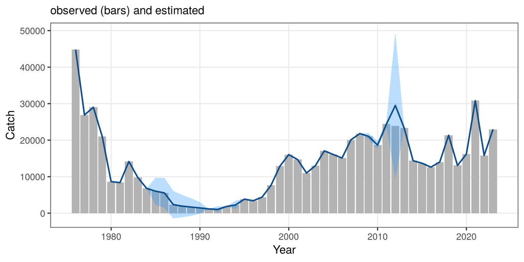

```r
jbplot_catch(fit)
```

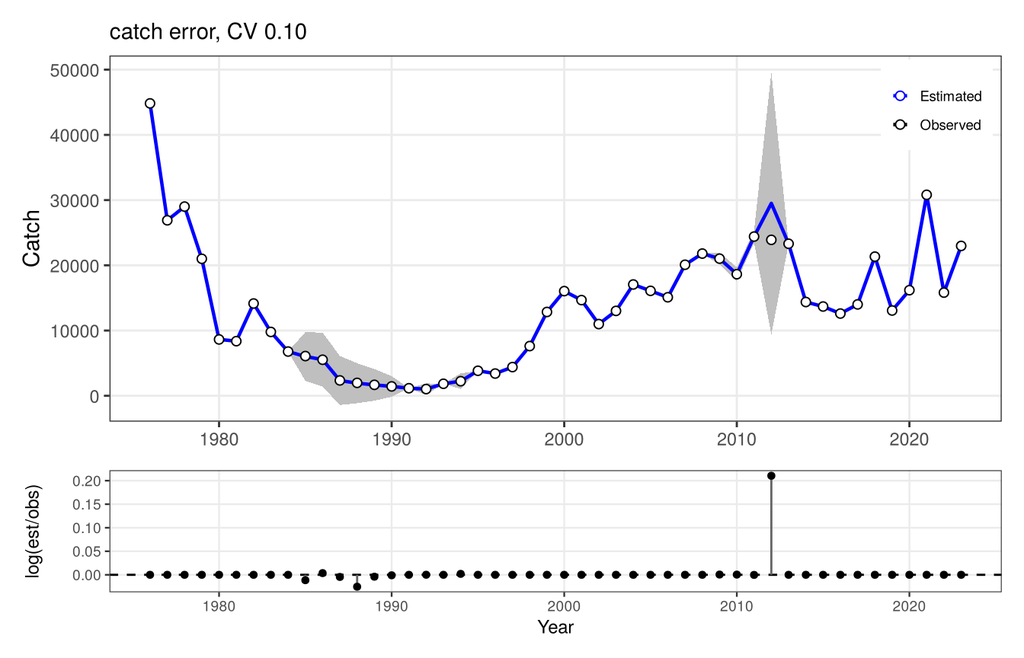

```r
jbplot_catcherror(fit)
```

## 9.3 Fast point estimates

For simulation testing, MSE and large grids, `se = FALSE, osa = FALSE` skips the standard errors and residuals:

```r
system.time(fq <- jabba3(d, pr, jb3_model(shape = "fox"), se = FALSE, osa = FALSE))
```

```
#>    user  system elapsed
#>   0.076   0.000   0.076
```

```r
fq$pars[c("K", "r"), "est"]
```

```
#> [1] 2.009940e+05 2.159748e-01
```

## 9.4 Full posterior with NUTS

`engine = "nuts"` samples all parameters and states of the same model with tmbstan (no Laplace approximation), started from the mode. Posterior medians and quantiles replace the mode summaries in `pars`, `refpts` and `ts`.

```r
fn <- jabba3(d, pr, jb3_model(shape = "fox"), engine = "nuts",
             nuts = list(chains = 3, iter = 1000, cores = 3))
fn
```

```
#> JABBA3 fit: illustrative ( illustrative )  engine: nuts  + 1500 nuts draws
#>   model: fox
#>   convergence: ok (max gradient 2.6e-11, Newton decrement 1.9e-22); NUTS Rhat max 1.025, ESS min 165, divergent 0
#>   estimates (posterior median, 95% CrI):
#>             est      lci      uci
#> K      2.43e+05 1.39e+05 4.49e+05
#> r      1.72e-01 8.15e-02 3.37e-01
#> bkinit 9.52e-01 6.31e-01 1.32e+00
#> sdb    1.02e-01 6.75e-02 1.55e-01
#> q1     8.02e-06 4.44e-06 1.45e-05
#> sdi1   4.21e-02 1.67e-02 1.06e-01
#> m      1.00e+00 1.00e+00 1.00e+00
#> Bmsy   8.95e+04 5.10e+04 1.65e+05
#> Fmsy   1.72e-01 8.15e-02 3.36e-01
#> MSY    1.56e+04 1.11e+04 2.03e+04
#>   status 2023: B/Bmsy 0.53 (0.37-0.75), F/Fmsy 2.80 (1.82-4.43)
```

> 1000 iterations per chain keep this guide fast; use at least 2000 (and check the NUTS diagnostics, section *NUTS diagnostics*) for final runs.

## 9.5 Fit to the indices

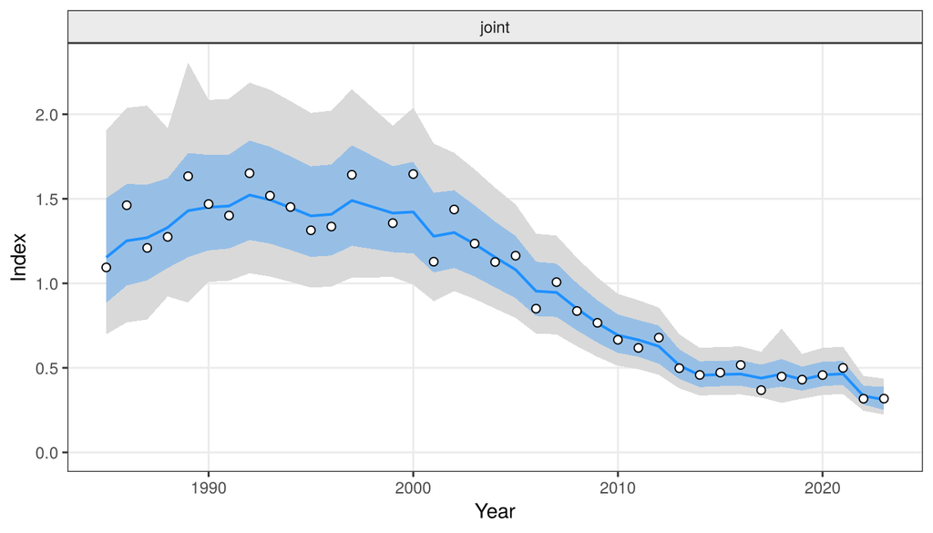

```r
jbplot_fits(fit)
```

`jbplot_fits(fit, log = TRUE)` plots on the log scale; the shaded band is the posterior predictive interval including observation error.

## 9.6 Production function and process deviations

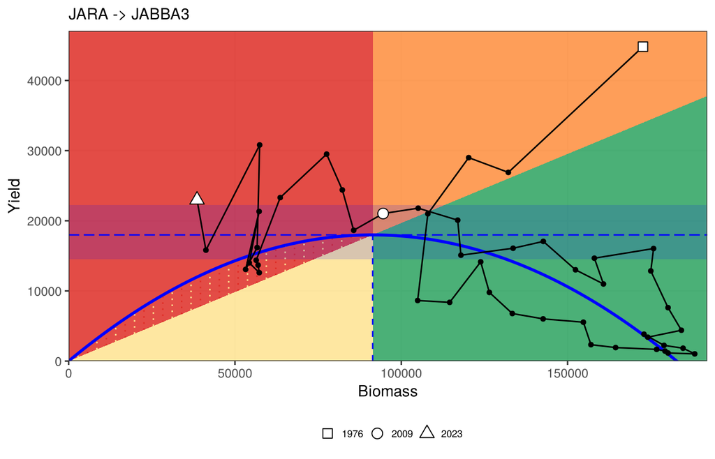

```r
jbplot_spphase(fit)
```

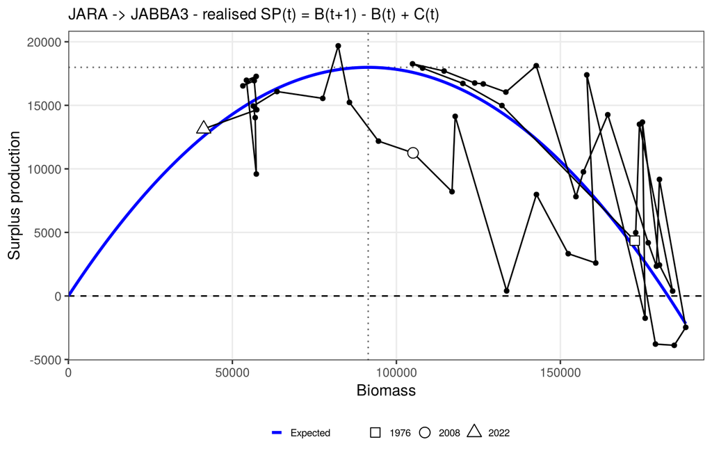

```r
jbplot_spdyn(fit)
```

`jbplot_spphase()` (as JABBA’s `jbplot_spphase()`) plots the catch against biomass over the production curve on the Kobe colours mapped to production space: below the line $C = F_{MSY} B$ the stock is fished below $F_{MSY}$. The hatched band left of $B_{MSY}$ marks catches below the production curve but above that line. `jbplot_spdyn()` plots the realised surplus production, $B_{t+1} - B_t + C_t$, against the expected curve; departures are the process deviations (and the lag) in production units. `rel = TRUE` gives $B/K$ and $C/MSY$ axes, and `jbplot_production(fit, type = "phase" | "dyn")` calls either.

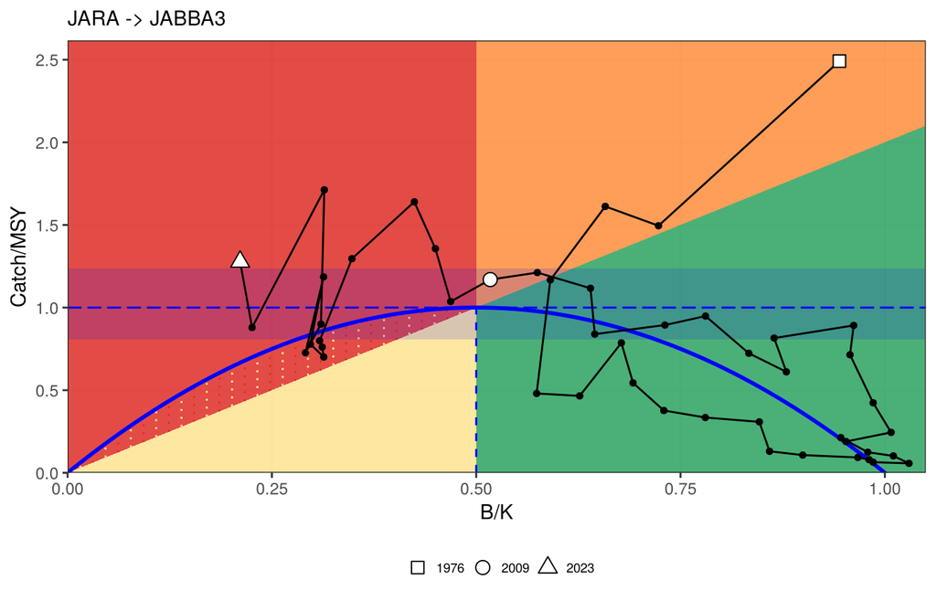

```r
jbplot_production(fit, type = "phase", rel = TRUE)
```

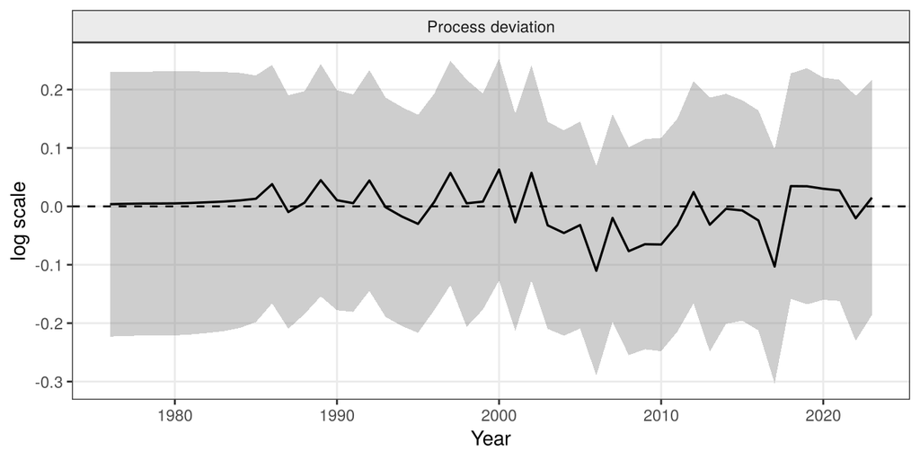

| What | Red flag | Action |
| --- | --- | --- |
| process deviations | long runs of the same sign | persistence: AR(1) with `rho = 0.75` and the lag |
| production plot | catch persistently above the production curve while biomass increases | the production function is wrong for the data: lag, shape, index trends |

```r
jbplot_procdev(fit)
```

## 9.7 Tables

`jb3_partable()` lists parameters, reference points and terminal status with 95% intervals; with a list of fits and `format = "wide"` it compares runs side by side. `jb3_tstable()` gives the time series of estimated quantities by year.

```r
knitr::kable(jb3_partable(fit), digits = 4)
```

| run | par | est | lci | uci | cv |
| --- | --- | --- | --- | --- | --- |
| JARA -> JABBA3 | K | 182810.7375 | 117150.2438 | 285272.6950 | 0.2270 |
| JARA -> JABBA3 | r | 0.3936 | 0.2390 | 0.6482 | 0.2545 |
| JARA -> JABBA3 | m | 2.0000 | NA | NA | NA |
| JARA -> JABBA3 | Bmsy/K | 0.5000 | NA | NA | NA |
| JARA -> JABBA3 | Bmsy | 91405.3688 | 58575.1219 | 142636.3475 | 0.2270 |
| JARA -> JABBA3 | Fmsy | 0.1968 | 0.1195 | 0.3241 | 0.2545 |
| JARA -> JABBA3 | MSY | 17988.7991 | 14528.1527 | 22273.7813 | 0.1090 |
| JARA -> JABBA3 | B1/K | 0.9409 | 0.6039 | 1.4660 | 0.2262 |
| JARA -> JABBA3 | sigma.proc | 0.1168 | 0.0787 | 0.1735 | 0.2019 |
| JARA -> JABBA3 | rho | 0.0000 | NA | NA | NA |
| JARA -> JABBA3 | q1 | 0.0000 | 0.0000 | 0.0000 | 0.2346 |
| JARA -> JABBA3 | sdi1 | 0.0424 | 0.0167 | 0.1074 | 0.4744 |
| JARA -> JABBA3 | B/Bmsy (2023) | 0.4222 | 0.3211 | 0.5552 | 0.1397 |
| JARA -> JABBA3 | F/Fmsy (2023) | 3.0249 | 2.1114 | 4.3337 | 0.1834 |
| JARA -> JABBA3 | B/K (2023) | 0.2111 | 0.1606 | 0.2776 | 0.1397 |

```r
knitr::kable(jb3_partable(list(Fox = fit, Lag.AR1 = rec), format = "wide"))
```

| Parameter | Fox | Lag.AR1 |
| --- | --- | --- |
| K | 183,000 (117,000-285,000) | 267,000 (143,000-500,000) |
| r | 0.394 (0.239-0.648) | 0.177 (0.0875-0.359) |
| m | 2 | 1 |
| Bmsy/K | 0.5 | 0.368 |
| Bmsy | 91,400 (58,600-143,000) | 98,200 (52,500-184,000) |
| Fmsy | 0.197 (0.12-0.324) | 0.177 (0.0874-0.359) |
| MSY | 18,000 (14,500-22,300) | 17,400 (11,600-26,000) |
| B1/K | 0.941 (0.604-1.47) | 0.898 (0.56-1.44) |
| sigma.proc | 0.117 (0.0787-0.174) | 0.0914 (0.0556-0.15) |
| rho | 0 | 0.75 |
| q1 | 0.00000809 (0.00000511-0.0000128) | 0.00000703 (0.00000353-0.000014) |
| sdi1 | 0.0424 (0.0167-0.107) | 0.043 (0.0169-0.11) |
| B/Bmsy | 0.422 (0.321-0.555) | 0.472 (0.26-0.857) |
| F/Fmsy | 3.02 (2.11-4.33) | 2.8 (1.37- 5.7) |
| B/K | 0.211 (0.161-0.278) | 0.174 (0.0956-0.315) |

```r
knitr::kable(tail(jb3_tstable(fit, c("Catch", "B/Bmsy", "F/Fmsy")), 5), digits = 3)
```

|  | year | Catch | Catch.lci | Catch.uci | B/Bmsy | B/Bmsy.lci | B/Bmsy.uci | F/Fmsy | F/Fmsy.lci | F/Fmsy.uci |
| --- | --- | --- | --- | --- | --- | --- | --- | --- | --- | --- |
| 44 | 2019 | 13068.99 | 13043.38 | 13094.61 | 0.582 | 0.469 | 0.722 | 1.248 | 0.944 | 1.651 |
| 45 | 2020 | 16184.99 | 16153.27 | 16216.71 | 0.620 | 0.504 | 0.762 | 1.451 | 1.103 | 1.909 |
| 46 | 2021 | 30810.03 | 30749.65 | 30870.42 | 0.628 | 0.516 | 0.765 | 2.726 | 2.085 | 3.565 |
| 47 | 2022 | 15815.99 | 15784.99 | 15846.99 | 0.451 | 0.361 | 0.564 | 1.948 | 1.446 | 2.623 |
| 48 | 2023 | 22976.00 | 22930.97 | 23021.03 | 0.422 | 0.321 | 0.555 | 3.025 | 2.111 | 4.334 |

# 10 Check 3: convergence

`jb3_convergence()` follows FLicc: the optimiser code, the largest gradient, a positive definite Hessian, finite standard errors and the Newton decrement (the expected further decrease of the objective by one Newton step). The fit is classed `ok`, `warning` or `failed`.

```r
jb3_convergence(fit)
```

```
#>                       check    value pass
#> 1            optimiser code 0.00e+00 TRUE
#> 2              max gradient 3.76e-11 TRUE
#> 3 Hessian positive definite 1.00e+00 TRUE
#> 4           standard errors 1.00e+00 TRUE
#> 5          Newton decrement 8.43e-23 TRUE
#>                                                                                    meaning
#> 1                                                          nlminb reported convergence (0)
#> 2                                       largest absolute gradient at the optimum (< 0.001)
#> 3                              the mode is a proper minimum (curvature in every direction)
#> 4                                                              all delta-method SEs finite
#> 5 expected further decrease of the objective by a Newton step (< 0.001 ok, <= 0.1 warning)
```

```r
fit$convergence$tier
```

```
#> [1] "ok"
```

| What | Red flag | Action |
| --- | --- | --- |
| max gradient | > 0.001 | refit (`nstart`), check priors and bounds |
| Hessian | not positive definite | a parameter is not identified: priors on r or K, fewer q or variance groups |
| Newton decrement | > 0.1 | not at the optimum; simplify the model |
| estimates at bounds | K at `K.bound`, B/K at `P.bound` | prior-data conflict; revisit priors |

The fit internally polishes the optimum with Newton steps and restarts from jittered values when the gradient is large (`nstart`).

# 11 Check 4: residual diagnostics

## 11.1 One-step-ahead residuals

The residuals of a state-space model computed from the smoothed states are shrunk and autocorrelated by construction, so the classic tests are biased. JABBA3 computes **one-step-ahead (OSA) residuals** (Thygesen et al. 2017) by a particle filter (`jb3_osa()`, run by `jabba3(osa = TRUE)`): each observation is predicted from the data up to the previous one. Under a correct model they are independent N(0, 1).

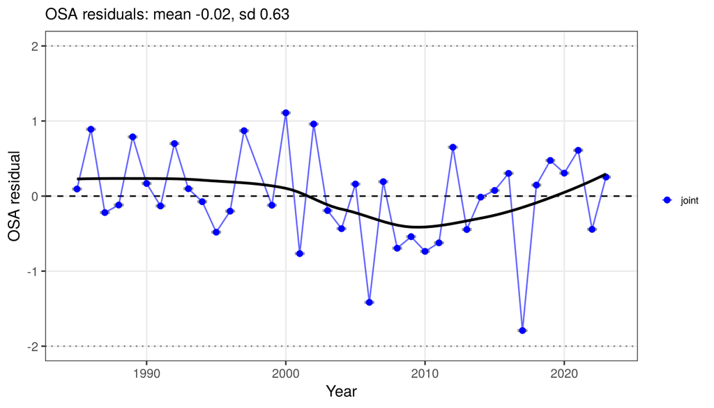

```r
jbplot_residuals(fit)
```

`jbplot_residuals(fit, type = "ordinary")` shows the classic log residuals.

`jbplot_stdresiduals()` shows the ordinary residuals standardised by the total observation SD, as JABBA’s plot of the same name, with SDNR and its 95% critical value:

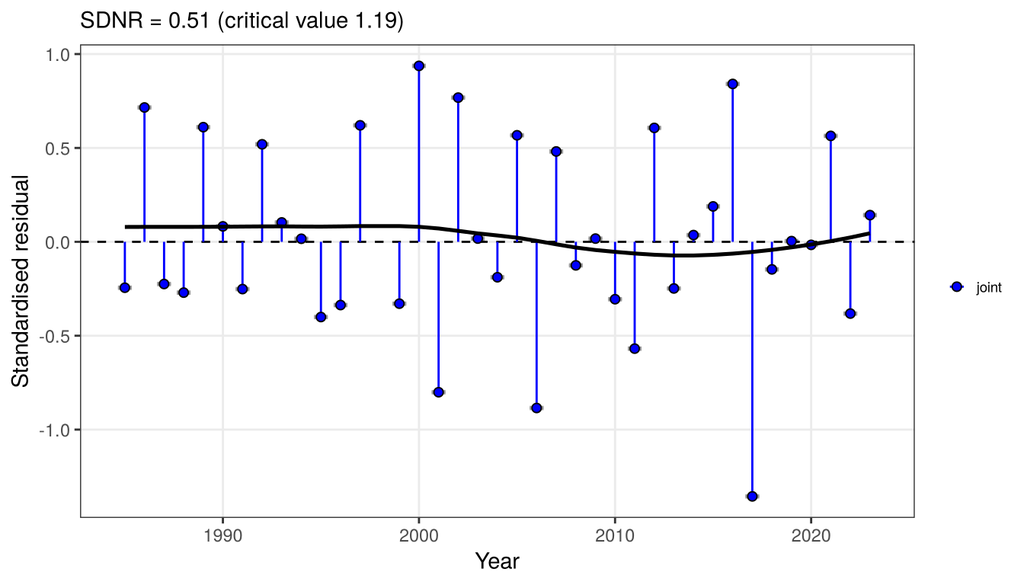

```r
jbplot_stdresiduals(fit)
```

## 11.2 Posterior predictive check

`jbplot_ppc()` compares, draw by draw, the discrepancy of the observed indices from the fitted ones, $D = \sum ((\log I - \log \hat{I})/\sigma)^2$, with that of indices replicated from the observation model (as JABBA’s `jbplot_PPC()`). The Bayesian p-value $P(D^{rep} > D^{obs})$ is near 0.5 for a well-specified observation model; values near 1 mean the indices are fitted more closely than the observation error implies (here the process error absorbs part of the index variation), values near 0 that they are fitted less well. It uses the draws of the fit (NUTS or MVN) and generates MVN draws if there are none.

```r
pp <- jbplot_ppc(fit)
attr(pp, "ppc")
```

```
#>       index Bayesian.p nobs
#> joint joint      0.916   38
```

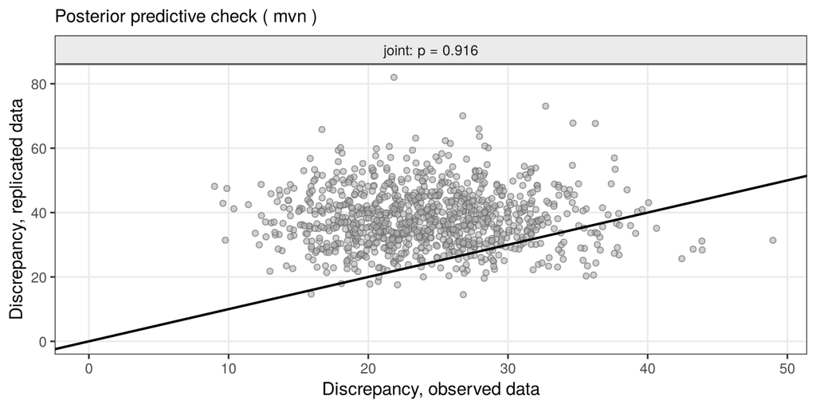

```r
pp
```

## 11.3 Runs tests

The runs test (Wald-Wolfowitz) checks for too few runs of residual signs (autocorrelation), with three-sigma limits from the average moving range (as JABBA, ss3diags and JAGG). Green: passed ($p \ge 0.05$); red: failed.

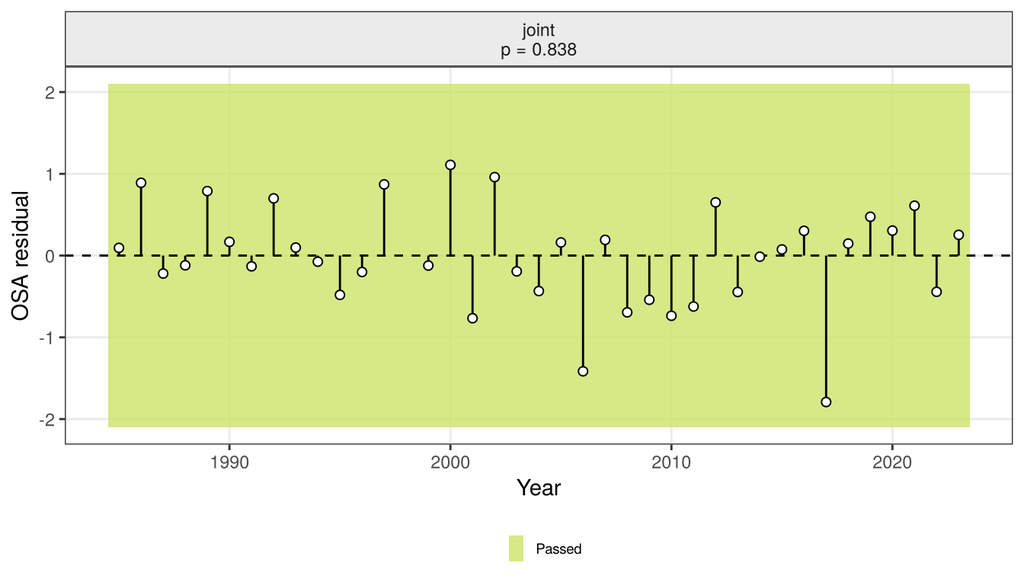

```r
jbplot_runs(fit)
```

The test table is in the plot’s attribute `"runs"` (`attr(jbplot_runs(fit), "runs")`); `mixing = "two.sided"` also flags too many runs. Likewise `jbplot_retro()` and `jbplot_hcxval()` return Mohn’s rho and MASE in attributes `"rho"` and `"mase"`.

## 11.4 The JABBA and SPiCT test sets

`jb3_diags()` gives one table per index: RMSE, SDNR, runs test and the share outside the three-sigma limits (the JABBA set), and the bias t-test, Ljung-Box test (lag 4) and Shapiro-Wilk normality test (the SPiCT set, as `plotspict.diagnostic()`). `flag` is `TRUE` when any test has $p < 0.05$.

```r
jb3_diags(fit)
```

```
#>   index  n       RMSE      SDNR runs.p out.3sig    bias.p LjungBox.p Shapiro.p
#> 1 joint 38 0.07488198 0.6304912  0.838        0 0.8779314  0.5389475 0.3449542
#>    flag
#> 1 FALSE
```

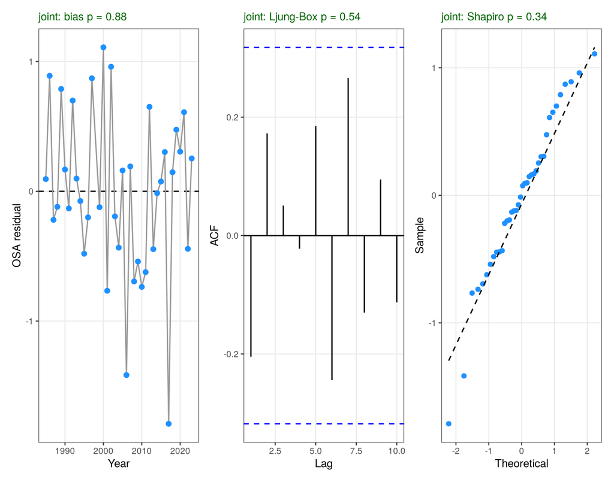

```r
jbplot_spdiags(fit)
```

> Residual tests check the error assumptions; they have little power to detect structural misspecification such as an omitted production lag. Use the retrospective and hindcast as well.

## 11.5 Retrospective analysis

`jb3_retro()` refits with the last 1 to `n` years of all data removed and computes Mohn’s rho.

```r
rt <- jb3_retro(fit, n = 5)
rt$rho
```

```
#>        quantity         rho
#> B             B -0.04634689
#> B/Bmsy   B/Bmsy -0.03268089
#> F             F  0.05236361
#> F/Fmsy   F/Fmsy  0.05592050
```

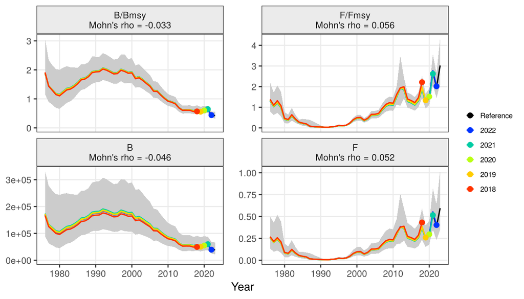

```r
jbplot_retro(rt)
```

## 11.6 Hindcast cross-validation

`jb3_hindcast()` removes the last 1 to `n` years of the indices (catch kept), predicts each removed observation one step ahead, and computes the mean absolute scaled error (MASE; Kell et al. 2021; Carvalho et al. 2021), the prediction error relative to a naive prediction (the last observed value). MASE < 1: the model predicts better than the naive guess.

```r
hc <- jb3_hindcast(fit, n = 5)
hc$mase
```

```
#>       index      MASE  MASE.adj    MAE.PR  MAE.base n.eval
#> joint joint 0.8864749 0.8864749 0.1143617 0.1290073      5
```

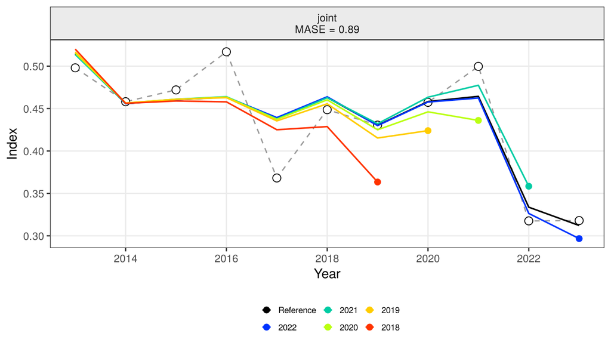

| What | Red flag | Action |
| --- | --- | --- |
| OSA residuals | trends, runs test failed | lag, AR(1), index conflict; separate `sdi` |
| Ljung-Box | p < 0.05 | autocorrelated residuals: process error persistence (AR(1)), or index trends in q |
| Mohn’s rho | beyond -0.15 to 0.20 | retrospective pattern; check recent data and q |
| MASE | > 1 | no prediction skill for that index |

```r
jbplot_hcxval(hc)
```

# 12 NUTS diagnostics

A NUTS fit has to be checked for convergence of the chains before its posterior is used. `jb3_nuts_diags()` gives the rank-normalised split $\hat{R}$, bulk and tail effective sample sizes (ESS; Vehtari et al. 2021) for every sampled parameter, including the states, and the sampler diagnostics by chain: divergent transitions, hits of the maximum tree depth, mean acceptance, step size and the energy Bayesian fraction of missing information (E-BFMI).

```r
nd <- jb3_nuts_diags(fn)
nd$sampler
```

```
#>   chain divergent treedepth.max    accept   stepsize     EBFMI
#> 1     1         0             0 0.9479576 0.04353705 0.5401036
#> 2     2         0             0 0.9656092 0.03857438 0.5960537
#> 3     3         0             0 0.9623860 0.03904694 0.6652577
```

```r
head(nd$pars, 8)
```

```
#>       par        mean        sd       q2.5         q50      q97.5     Rhat
#> 1    logK  2.88518562 0.3008028  2.3145525  2.87631113  3.4883100 1.002797
#> 2    logr -1.76731428 0.3663660 -2.5067545 -1.75766061 -1.0882827 1.001169
#> 3    logq -2.40037619 0.3012288 -3.0064418 -2.40134706 -1.8132632 1.006284
#> 4     lbk -0.05896808 0.1941460 -0.4609411 -0.04867408  0.2746337 1.000422
#> 5  logsdb -2.28442599 0.2083345 -2.6954038 -2.28744802 -1.8638456 1.005246
#> 6  logsdi -3.15167862 0.4216784 -3.9659343 -3.15178082 -2.3396217 1.002157
#> 7 logP[1] -0.05223884 0.1970614 -0.4659411 -0.03492181  0.2621419 1.001167
#> 8 logP[2] -0.25628742 0.2281516 -0.7337841 -0.23382610  0.1479088 1.002925
#>    ess_bulk  ess_tail
#> 1  558.0531  878.9970
#> 2  592.5226  895.2334
#> 3  551.4946  799.5947
#> 4  638.8159 1024.3742
#> 5  291.2095  669.9988
#> 6 2343.3658  970.1551
#> 7  475.0922  883.7967
#> 8  452.2529  721.9151
```

```r
nd$ok
```

```
#> [1] FALSE
```

`ok` is `TRUE` when $\hat{R} < 1.01$, bulk and tail ESS > 100 per chain, there are no divergent transitions and E-BFMI > 0.3 in all chains.

The plots are on the sampled scale (mostly logs): `logK`, `logr`, `logq[i]`, `lbk` (log initial depletion), `logsdb`, `logsdi[i]`, and the states `logP[t]` and catch deviations `cdev[t]`. By default only the fixed effects are plotted; `pars` selects parameters (`"logq"` matches all `logq[i]`).

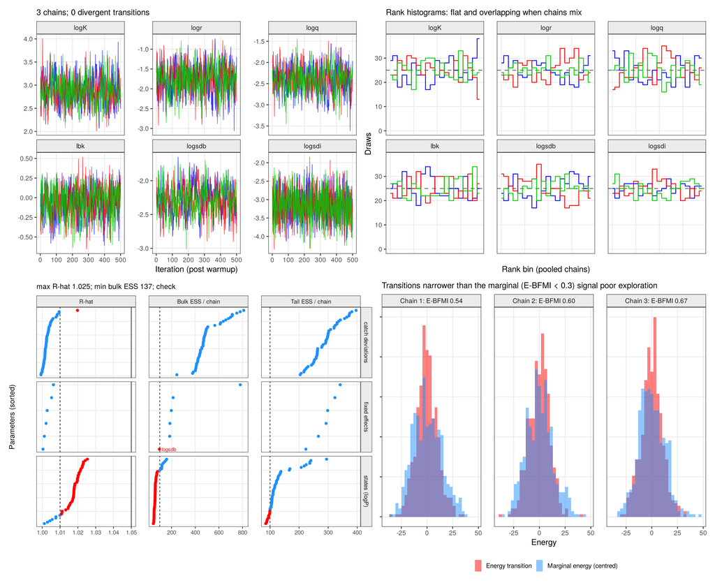

```r
jbplot_nutsdiags(fn)
```

`jbplot_nuts(fit, type)` gives the single plots:

| `type` | Shows | Healthy |
| --- | --- | --- |
| `"trace"` | traces by chain; divergent transitions as red rug ticks | chains overlap, no trends |
| `"rank"` | rank histograms by chain | flat and overlapping |
| `"dens"` | densities by chain | the same in all chains |
| `"acf"` | autocorrelation by chain | drops to zero within a few lags |
| `"pairs"` | pairwise scatter with divergent transitions in red | no funnels or ridges; divergences not clustered |
| `"rhat"` | $\hat{R}$ and ESS for all parameters, states included | $\hat{R} < 1.01$, ESS > 100 per chain |
| `"energy"` | marginal energy against energy transitions | similar widths (E-BFMI > 0.3) |

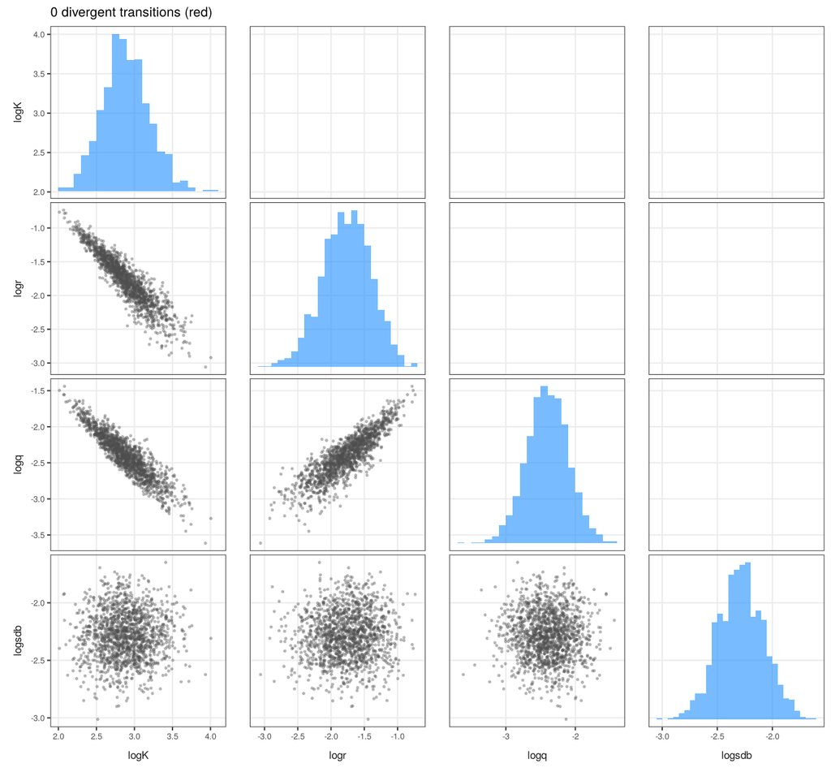

```r
jbplot_nuts(fn, "pairs", pars = c("logK", "logr", "logq", "logsdb"))
```

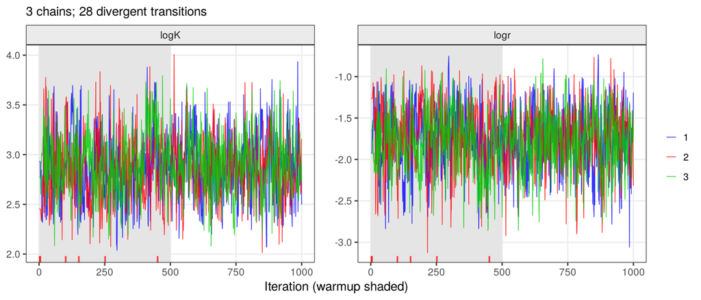

```r
jbplot_nuts(fn, "trace", pars = c("logK", "logr"), inc_warmup = TRUE)
```

Each type is also its own function: `jbplot_trace()`, `jbplot_rank()`, `jbplot_mcmcdens()`, `jbplot_mcmcacf()`, `jbplot_pairs()`, `jbplot_rhat()` and `jbplot_energy()`.

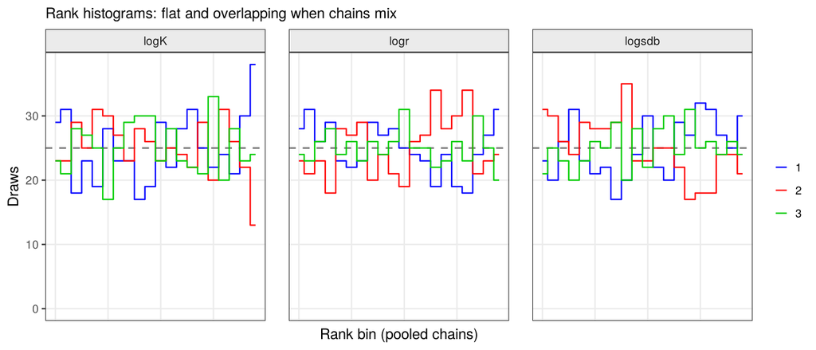

```r
jbplot_rank(fn, pars = c("logK", "logr", "logsdb"))
```

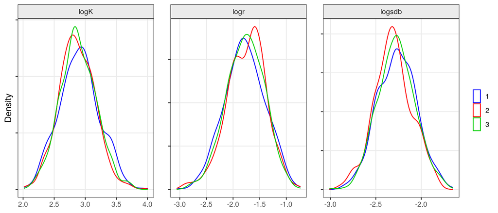

```r
jbplot_mcmcdens(fn, pars = c("logK", "logr", "logsdb"))
```

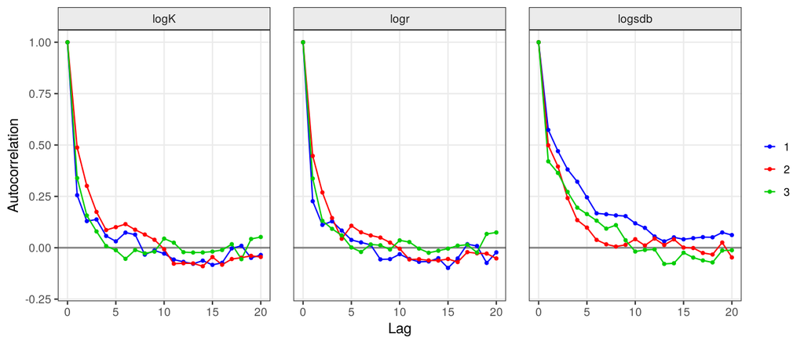

```r
jbplot_mcmcacf(fn, pars = c("logK", "logr", "logsdb"))
```

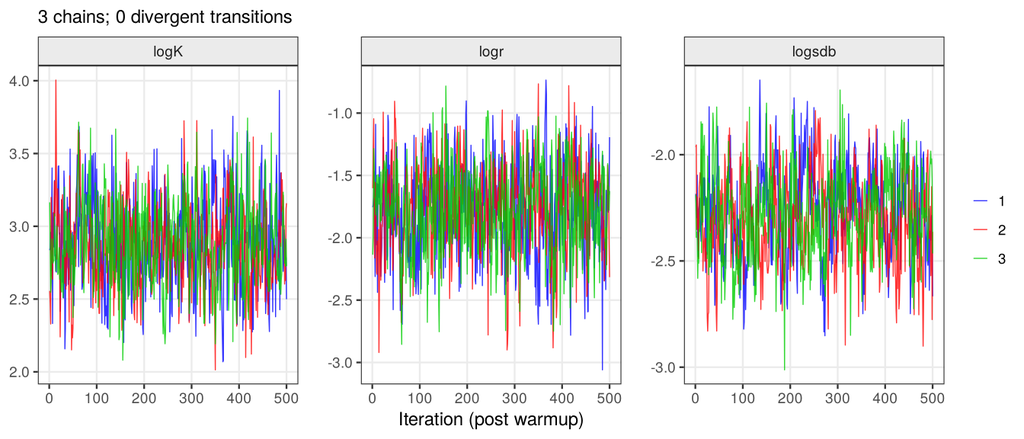

```r
jbplot_trace(fn, pars = c("logK", "logr", "logsdb"))
```

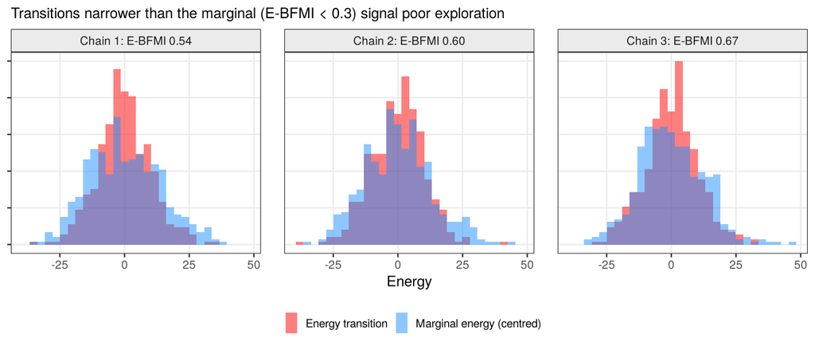

```r
jbplot_energy(fn)
```

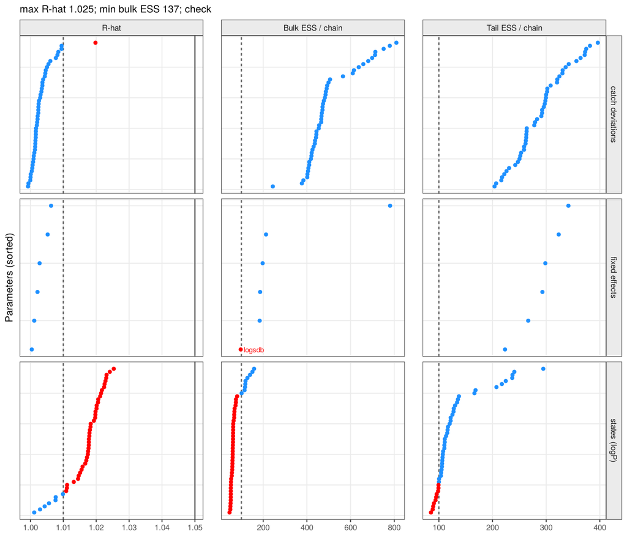

```r
jbplot_rhat(fn)
```

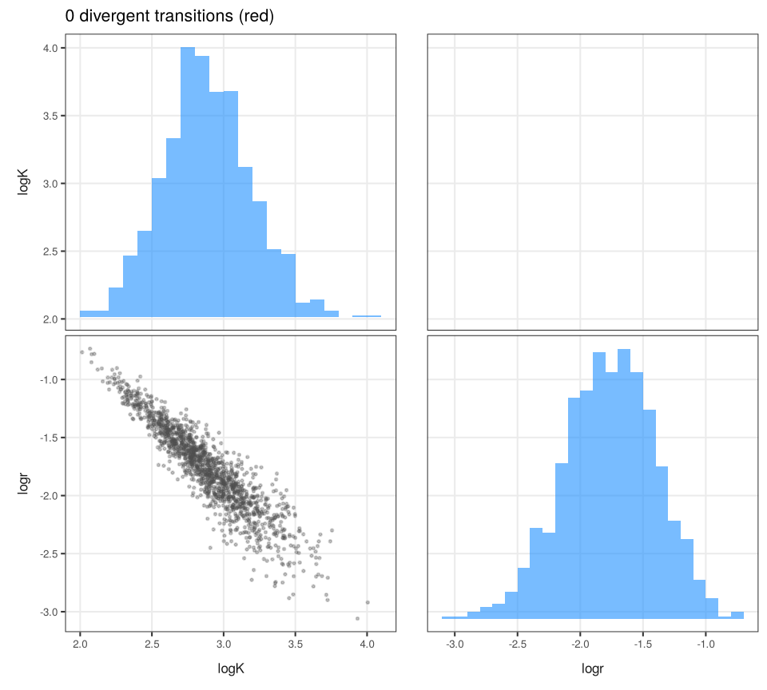

| What | Red flag | Action |
| --- | --- | --- |
| $\hat{R}$, ESS | $\hat{R} > 1.01$ or ESS < 100 per chain | more iterations (`iter`); check the pairs plot |
| divergent transitions | any | `control = list(adapt_delta = 0.99)`; look where they cluster in the pairs plot |
| tree depth | many hits of `max_treedepth` | strong correlations (K and r, K and q): tighter priors |
| E-BFMI | < 0.3 | poor exploration of the tails, often the process error SD and the states |
| K-r-q ridge | strong negative correlation of log K with log r and log q | expected with little contrast; informative r prior |

```r
jbplot_pairs(fn, pars = c("logK", "logr"))
```

> In the short run above the states (`logP`) have low ESS: with process error SDs around 0.1 the states and `logsdb` form a funnel. Run longer for final results.

# 13 BioProcDyn workflows

The workflows of the BioProcDyn protocol run automatically with `jabba3(..., workflow = )`, or step by step with `jb3_tier1()` and `jb3_tier2()` on any fit. All steps are kept in `$steps`.

[output not shown]

```r
wf <- jabba3(d, pr, jb3_model(shape = "fox"), workflow = "tier2", amat = 3)
names(wf$steps)
```

```
#> [1] "Current" "Tier 2"
```

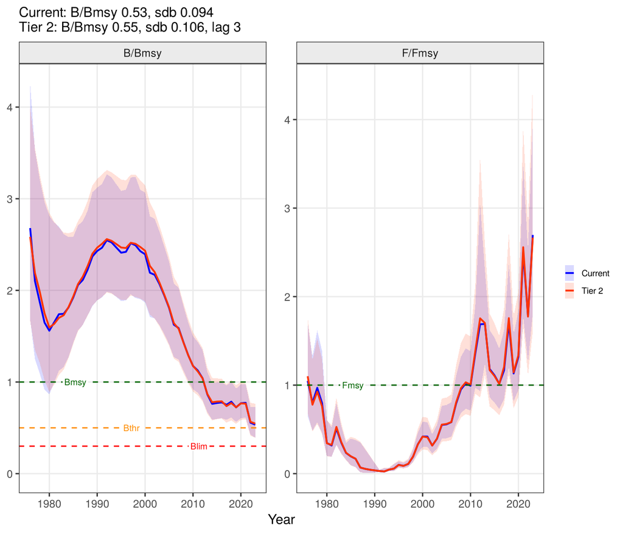

```r
jbplot_steps(wf)
```

Step by step, from an existing fit:

```r
t1 <- jb3_tier1(fit, amat = 3)
t1$model$lag
```

```
#> [1] 3
```

> The BioProcDyn simulations found that the depletion-dependent process error of Tier 2, although present in the operating models, did not remove the optimism; lag + AR(1) (`jb3_model(lag = amat, rho = 0.75)`) did. The tiers are kept for comparison and sensitivity.

# 14 Projections

`jb3_project()` projects the stock under constant $F/F_{MSY}$ scenarios (`fmsy`, the default: 0, 0.5, 0.75, 1 and 1.25 $F_{MSY}$) or constant catch (`catch`), from the NUTS draws or from MVN draws at the mode (generated if the fit has none), with process error (and its AR(1) persistence and the lag). F-based scenarios apply $F = f \times F_{MSY}$ draw by draw, so they remain defined when a draw is depleted; constant catches are capped at 95% of the biomass.

```r
pj <- jb3_project(fit, fmsy = c(0, 0.5, 0.75, 1, 1.25), nyears = 10)
pj$scenarios
```

```
#>     type value         label
#> 1 F/Fmsy  0.00    F/Fmsy = 0
#> 2 F/Fmsy  0.50  F/Fmsy = 0.5
#> 3 F/Fmsy  0.75 F/Fmsy = 0.75
#> 4 F/Fmsy  1.00    F/Fmsy = 1
#> 5 F/Fmsy  1.25 F/Fmsy = 1.25
```

Process error in the projection years follows the fitted model. With the default `procerr = "ar1"`, each draw continues its AR(1) process from its last estimated deviation, $d_{t+1} = \rho d_t + \varepsilon_t$ with $\varepsilon_t \sim N(0, \sigma^2(1-\rho^2))$, so the persistence carries into the forecast and the marginal SD stays $\sigma$ (with $\rho = 0$ this is the iid sampling of JABBA’s `fw_jabba()`). `procerr = "mean"` uses only the conditional mean $\rho^h d_T$ and `"none"` deterministic production. Projection tables report the risk $P(B < B_{lim})$ with $B_{lim} = 0.3 B_{MSY}$ by default.

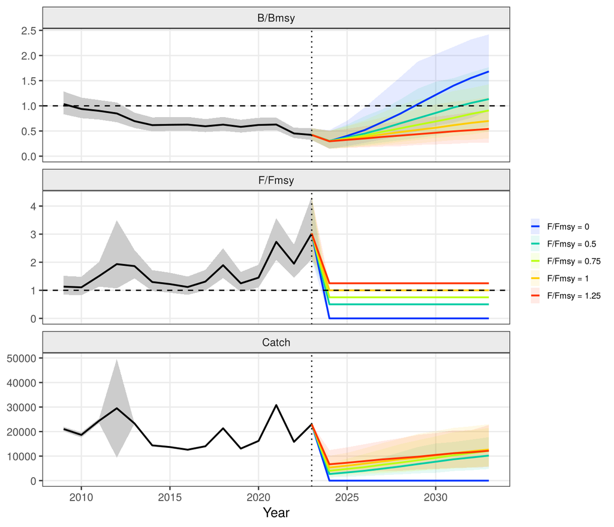

```r
jbplot_projection(pj)
```

## 14.1 Projection tables

`jb3_projtable()` gives a catch options table in the style of an ICES advice sheet: $F/F_{MSY}$, $F$ and the catch in the first projection year, the median $B/B_{MSY}$ in selected years with the change relative to the terminal year, and the probabilities of $B \ge B_{MSY}$, $F \le F_{MSY}$ and of the Kobe green quadrant.

```r
knitr::kable(jb3_projtable(pj, years = c(2018, 2022, 2027)))
```

| scenario | F/Fmsy | F | Catch 2024 | B/Bmsy 2018 | dB% 2018 | P(B>=Bmsy) 2018 | P(B<Blim) 2018 | P(F<=Fmsy) 2018 | P(green) 2018 | B/Bmsy 2022 | dB% 2022 | P(B>=Bmsy) 2022 | P(B<Blim) 2022 | P(F<=Fmsy) 2022 | P(green) 2022 | B/Bmsy 2027 | dB% 2027 | P(B>=Bmsy) 2027 | P(B<Blim) 2027 | P(F<=Fmsy) 2027 | P(green) 2027 |
| --- | --- | --- | --- | --- | --- | --- | --- | --- | --- | --- | --- | --- | --- | --- | --- | --- | --- | --- | --- | --- | --- |
| F/Fmsy = 0 | 0.00 | 0.000 | 0 | NA | NA | NA | NA | NA | NA | NA | NA | NA | NA | NA | NA | 0.679 | 60.80 | 0.119 | 0.014 | 1 | 0.119 |
| F/Fmsy = 0.5 | 0.50 | 0.098 | 2690 | NA | NA | NA | NA | NA | NA | NA | NA | NA | NA | NA | NA | 0.546 | 29.20 | 0.012 | 0.040 | 1 | 0.012 |
| F/Fmsy = 0.75 | 0.75 | 0.147 | 4010 | NA | NA | NA | NA | NA | NA | NA | NA | NA | NA | NA | NA | 0.485 | 14.90 | 0.002 | 0.077 | 1 | 0.002 |
| F/Fmsy = 1 | 1.00 | 0.196 | 5350 | NA | NA | NA | NA | NA | NA | NA | NA | NA | NA | NA | NA | 0.433 | 2.52 | 0.006 | 0.130 | 1 | 0.006 |
| F/Fmsy = 1.25 | 1.25 | 0.245 | 6660 | NA | NA | NA | NA | NA | NA | NA | NA | NA | NA | NA | NA | 0.383 | -9.26 | 0.000 | 0.233 | 0 | 0.000 |

`jb3_kobematrix()` is the Kobe II strategy matrix (ICCAT): the probability of being in the green quadrant by scenario and year (`what = "B"` or `"F"` for one reference point only).

```r
knitr::kable(jb3_kobematrix(pj))
```

|  | scenario | 2024 | 2025 | 2026 | 2027 | 2028 | 2029 | 2030 | 2031 | 2032 | 2033 |
| --- | --- | --- | --- | --- | --- | --- | --- | --- | --- | --- | --- |
| F/Fmsy = 0 | F/Fmsy = 0 | 0 | 0 | 0.02 | 0.12 | 0.30 | 0.53 | 0.73 | 0.85 | 0.91 | 0.96 |
| F/Fmsy = 0.5 | F/Fmsy = 0.5 | 0 | 0 | 0.00 | 0.01 | 0.07 | 0.18 | 0.30 | 0.45 | 0.58 | 0.68 |
| F/Fmsy = 0.75 | F/Fmsy = 0.75 | 0 | 0 | 0.00 | 0.00 | 0.03 | 0.06 | 0.11 | 0.18 | 0.27 | 0.36 |
| F/Fmsy = 1 | F/Fmsy = 1 | 0 | 0 | 0.00 | 0.01 | 0.01 | 0.02 | 0.03 | 0.05 | 0.07 | 0.10 |
| F/Fmsy = 1.25 | F/Fmsy = 1.25 | 0 | 0 | 0.00 | 0.00 | 0.00 | 0.00 | 0.00 | 0.00 | 0.00 | 0.00 |

Constant catch scenarios remain available, e.g. for TAC options:

```r
pc <- jb3_project(rec, catch = c(60000, 70000, 80000), nyears = 10)
knitr::kable(jb3_projtable(pc)[, 1:9])
```

| scenario | F/Fmsy | F | Catch 2024 | B/Bmsy 2024 | dB% 2024 | P(B>=Bmsy) 2024 | P(B<Blim) 2024 | P(F<=Fmsy) 2024 |
| --- | --- | --- | --- | --- | --- | --- | --- | --- |
| Catch = 60000 | 5.38 | 0.95 | 36300 | 0.383 | -18.7 | 0.002 | 0.265 | 0 |
| Catch = 70000 | 5.45 | 0.95 | 36100 | 0.384 | -18.7 | 0.003 | 0.275 | 0 |
| Catch = 80000 | 5.49 | 0.95 | 35600 | 0.379 | -19.6 | 0.003 | 0.265 | 0 |

# 15 Comparing runs and risk

## 15.1 Ensembles and sensitivity runs

`jbplot_ensemble()` compares a list of fits (scenarios, sensitivity runs, the steps of a workflow), as JABBA’s plot of the same name: trajectories coloured by run and a Kobe plot with each run’s terminal uncertainty and its median. With `joint = TRUE` the runs are pooled with equal weights into one ensemble.

```r
fsch <- jabba3(d, jb3_priors(d, r = c(0.2, 0.5)), jb3_model(shape = "schaefer"), osa = FALSE)
runs <- list(Fox = fit, Schaefer = fsch, `Lag + AR(1)` = rec)
```

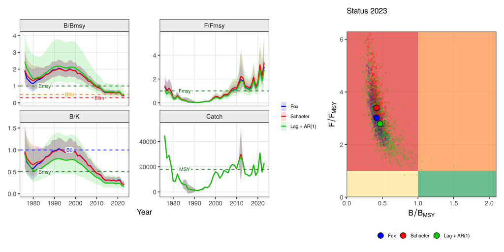

```r
jbplot_ensemble(runs)
```

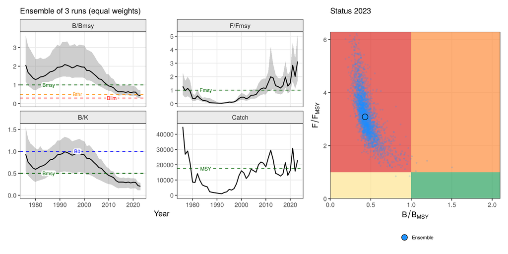

```r
jbplot_ensemble(runs, joint = TRUE)
```

`jbplot_summary()` gives the overview of JABBA’s `jbplot_summary()`: B, F, $B/B_{MSY}$, $F/F_{MSY}$ and $B/K$ by run, and the production curves with $B_{MSY}$ and MSY.

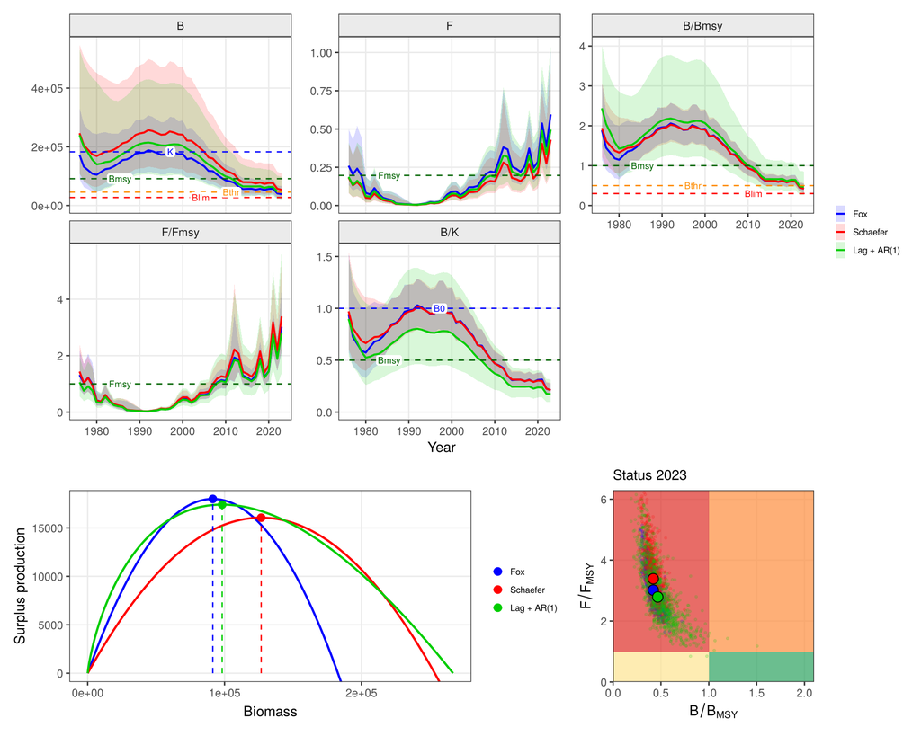

```r
jbplot_summary(runs)
```

`kobe = FALSE` drops the Kobe panel in `jbplot_summary()` and `jbplot_ensemble()`. `jabbaplot3()` takes a list of runs too, with a choice of panels:

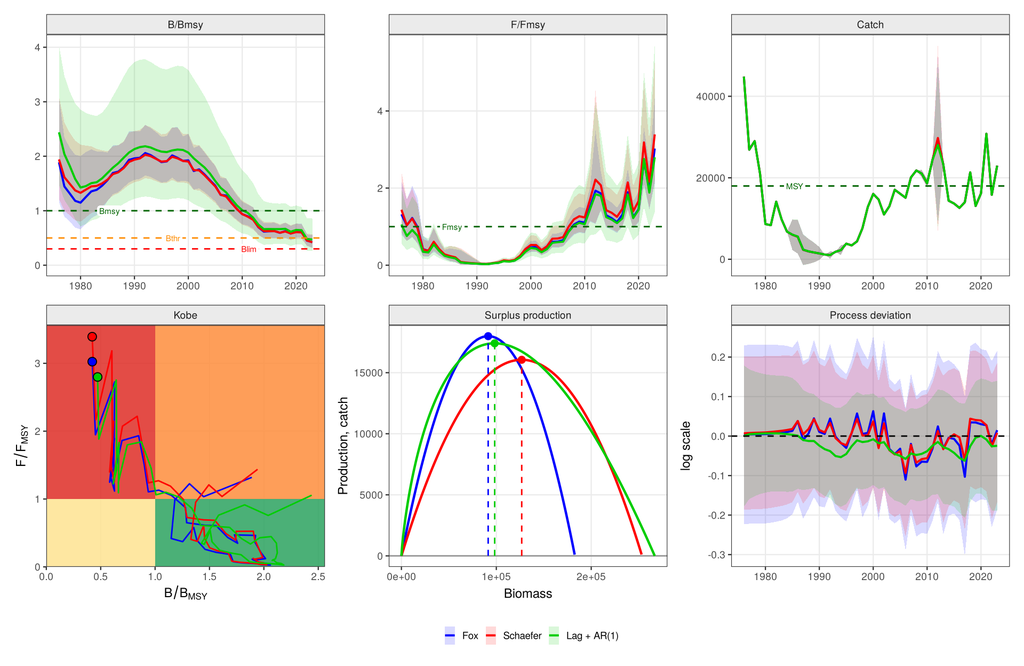

```r
jabbaplot3(runs, panels = c("B/Bmsy", "F/Fmsy", "Catch", "kobe", "production", "procdev"))
```

## 15.2 Projections on the advice plot

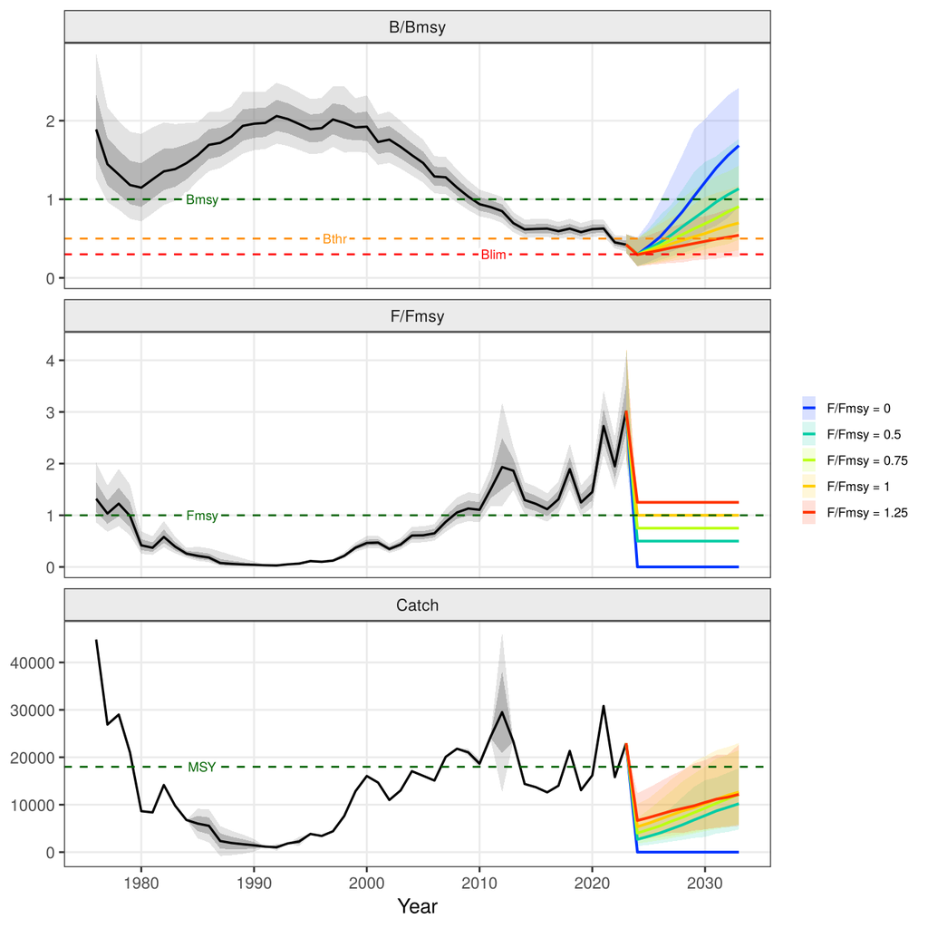

```r
jbplot_advice(fit, proj = pj)
```

## 15.3 Risk curves

`jbplot_crisk()` plots, as JABBA’s `jbplot_Crisk()`, the probability that $B < B_{MSY}$, that $F > F_{MSY}$ and that $B < 0.5 B_{MSY}$ (`bfrac`) against the scenario value (F/F<sub>MSY</sub> or catch), one line per projection year:

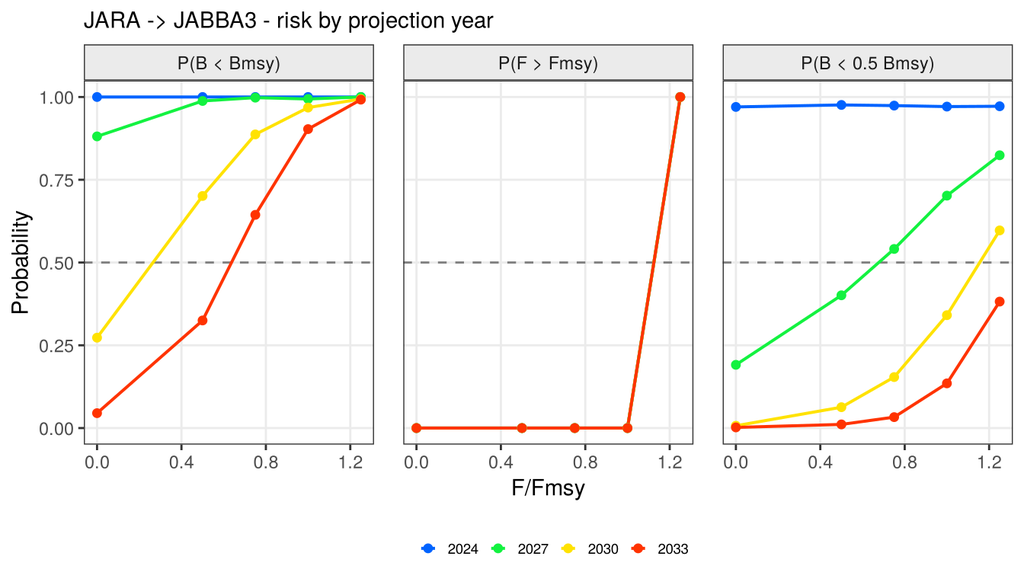

```r
jbplot_crisk(pj)
```

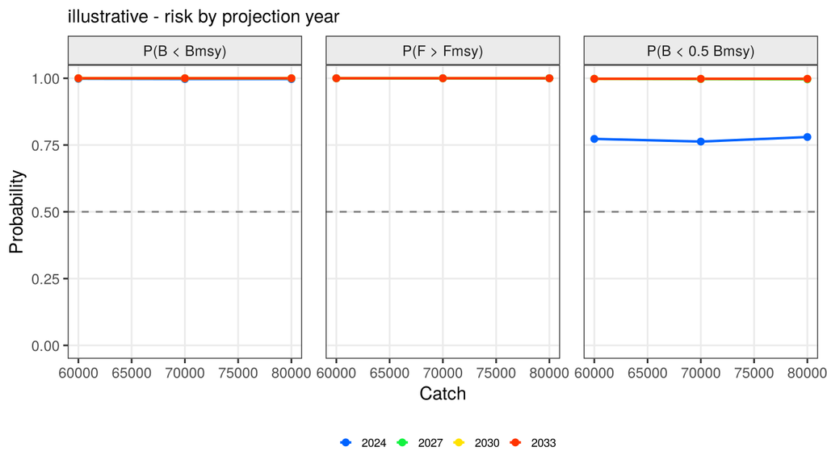

```r
jbplot_crisk(pc)
```

# 16 The rebuilding protocol: Atlantic blue marlin

Bigeye tuna is the standard example of this guide. This chapter is the more complex one: it introduces the BioProcDyn rebuilding protocol on a stock where it matters. The 2018 ICCAT assessment of Atlantic blue marlin (*Makaira nigricans*) used JABBA and Stock Synthesis (SS3), and the two differed markedly in how fast the stock was projected to rebuild. This chapter reproduces the 2018 JABBA base case, applies the BioProcDyn protocol step by step (life-history process error prior, production lag, persistent AR(1) process error) and compares status, diagnostics and forecasts.

## 16.1 The 2018 base case

The 2018 base case was a Pella-Tomlinson model with $B_{MSY}/K = 0.36$, an r prior of 0.098 (CV 0.18), an uninformative K prior, initial depletion near unfished, ten CPUE indices with an additional observation error of 0.25, and the process error fixed at $\sigma = 0.07$ and process deviations starting with the first index year. In JABBA3 (the additional observation variance is estimated by index):

```r
bum <- iccat$bum
d.bum  <- jb3_data(bum$catch, bum$cpue, bum$se, stock = "bum")
pr.bum <- jb3_priors(d.bum, r = c(0.098, 0.18), K = c(50000, sqrt(log(1 + 2^2))),
                     bkinit = c(1, sqrt(log(1 + 0.25^2))))
m.base <- jb3_model(shape = "pella", BmsyK = 0.36, sdb.fixed = 0.07, start = "index")
bum.base <- jabba3(d.bum, pr.bum, m.base, run = "2018 base")
bum.base
```

```
#> JABBA3 fit: 2018 base ( bum )  engine: rtmb
#>   model: pella
#>   convergence: ok (max gradient 1.3e-09, Newton decrement 1.0e-20)
#>   estimates (mode, 95% CI):
#>             est      lci      uci
#> K      9.15e+04 6.83e+04 1.22e+05
#> r      9.47e-02 6.99e-02 1.28e-01
#> bkinit 1.22e+00 1.11e+00 1.35e+00
#> sdb    7.00e-02       NA       NA
#> q1     1.58e-05 1.13e-05 2.21e-05
#> q2     1.60e-05 1.03e-05 2.48e-05
#> q3     3.07e-05 2.11e-05 4.45e-05
#> q4     3.43e-05 2.31e-05 5.09e-05
#> q5     2.57e-05 1.63e-05 4.07e-05
#> q6     2.91e-05 1.79e-05 4.73e-05
#> q7     1.55e-05 1.03e-05 2.33e-05
#> q8     2.54e-05 1.74e-05 3.72e-05
#> q9     3.42e-05 2.24e-05 5.23e-05
#> q10    2.43e-05 1.14e-05 5.16e-05
#> sdi1   1.20e-01 7.17e-02 2.00e-01
#> sdi2   6.65e-01 4.82e-01 9.17e-01
#> sdi3   1.86e-01 9.70e-02 3.56e-01
#> sdi4   2.10e-01 1.29e-01 3.43e-01
#> sdi5   2.12e-01 5.04e-02 8.92e-01
#> sdi6   6.46e-01 4.60e-01 9.08e-01
#> sdi7   6.55e-01 4.94e-01 8.67e-01
#> sdi8   4.04e-01 2.88e-01 5.68e-01
#> sdi9   1.61e-01 1.81e-02 1.42e+00
#> sdi10  9.92e-01 8.20e-01 1.20e+00
#> m      9.58e-01       NA       NA
#> Bmsy   3.29e+04 2.46e+04 4.41e+04
#> Fmsy   9.89e-02 7.30e-02 1.34e-01
#> MSY    3.25e+03 2.70e+03 3.93e+03
#>   status 2016: B/Bmsy 0.78 (0.55-1.13), F/Fmsy 0.80 (0.49-1.29)
```

The same fit follows from the original JABBA input with the converter (`jbinput2jabba3()`, chapter *Converting from JABBA and SPiCT*):

```r
jb.bum <- JABBA::build_jabba(catch = bum$catch, cpue = bum$cpue, se = bum$se,
  assessment = "BUM", scenario = "2018 base", model.type = "Pella", BmsyK = 0.36,
  K.prior = c(50000, 2), r.prior = c(0.098, 0.18), psi.prior = c(1, 0.25),
  fixed.obsE = 0.25, proc.dev.all = FALSE, sigma.proc = 0.07, verbose = FALSE)
x.bum <- jbinput2jabba3(jb.bum, keep.igamma = TRUE)
bum.base <- jabba3(x.bum$data, x.bum$priors, x.bum$model, run = "2018 base")
```

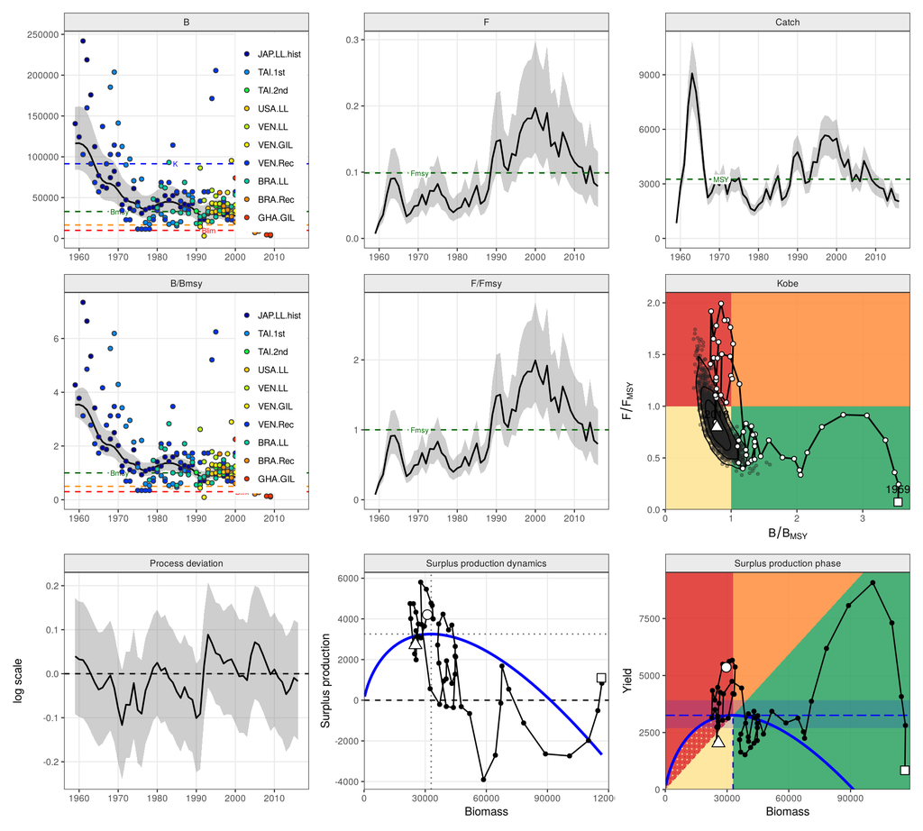

```r
plot(bum.base)
```

The fit is close to the 2018 JAGS assessment. Note the process deviations: with $\sigma$ fixed at a low value they form long runs of the same sign, a lag-1 autocorrelation of

```r
pd <- bum.base$ts$est[bum.base$ts$quantity == "Process deviation"]
round(acf(pd, plot = FALSE)$acf[2], 2)
```

```
#> [1] 0.78
```

This is the persistence that the BioProcDyn simulations identify as the source of rebuilding optimism: a model with independent process error absorbs the persistent part of the production anomalies into r and K.

## 16.2 Applying the protocol

Three steps, each added to the previous one:

1. **Life-history prior on the process error scale** (the JABBA3 default, $\sigma_{MSY} = 0.80 \sigma_R r^{0.45}$) instead of the fixed $\sigma = 0.07$;
2. **production lag** at the age at maturity (here 3 years);
3. **AR(1) process deviations** with $\rho = 0.75$ (the default; blue marlin falls in the 6-10 year generation-time class of `jb3_rho_table()`).

```r
# pr.bum already carries the life-history sdb prior (default); the base case fixed sdb in the model
mod <- function(lag = 0, rho = 0) jb3_model(shape = "pella", BmsyK = 0.36, start = "index", lag = lag, rho = rho)
bum.runs <- list(
  `2018 base`     = bum.base,
  `sdb prior`     = jabba3(d.bum, pr.bum, mod(),        run = "sdb prior"),
  `+ lag`         = jabba3(d.bum, pr.bum, mod(3),       run = "+ lag"),
  `+ lag + AR(1)` = jabba3(d.bum, pr.bum, mod(3, 0.75), run = "+ lag + AR(1)"))
pt <- jb3_partable(bum.runs, format = "wide")
knitr::kable(pt[pt$Parameter %in% c("K", "r", "Bmsy", "Fmsy", "MSY", "sigma.proc", "rho", "B/Bmsy", "F/Fmsy"), ], row.names = FALSE)
```

| Parameter | 2018 base | sdb prior | + lag | + lag + AR(1) |
| --- | --- | --- | --- | --- |
| K | 91,500 (68,300-122,000) | 93,800 (64,100-137,000) | 96,300 (66,400-140,000) | 98,600 (58,000-168,000) |
| r | 0.0947 (0.0699-0.128) | 0.0982 (0.0707-0.137) | 0.0972 (0.0706-0.134) | 0.104 (0.0738-0.146) |
| Bmsy | 32,900 (24,600-44,100) | 33,800 (23,100-49,500) | 34,700 (23,900-50,300) | 35,500 (20,900-60,300) |
| Fmsy | 0.0989 (0.073-0.134) | 0.103 (0.0738-0.143) | 0.101 (0.0737-0.14) | 0.108 (0.077-0.153) |
| MSY | 3,250 (2,700-3,930) | 3,460 (2,590-4,630) | 3,520 (2,650-4,670) | 3,850 (2,400-6,180) |
| sigma.proc | 0.07 | 0.14 (0.102-0.192) | 0.138 ( 0.1-0.191) | 0.117 (0.0762-0.18) |
| rho | 0 | 0 | 0 | 0.75 |
| B/Bmsy | 0.784 (0.545-1.13) | 0.605 (0.403-0.907) | 0.581 (0.376-0.897) | 0.409 (0.209-0.801) |
| F/Fmsy | 0.798 (0.494-1.29) | 0.971 (0.563-1.68) | 0.996 (0.573-1.73) | 1.29 (0.654-2.55) |

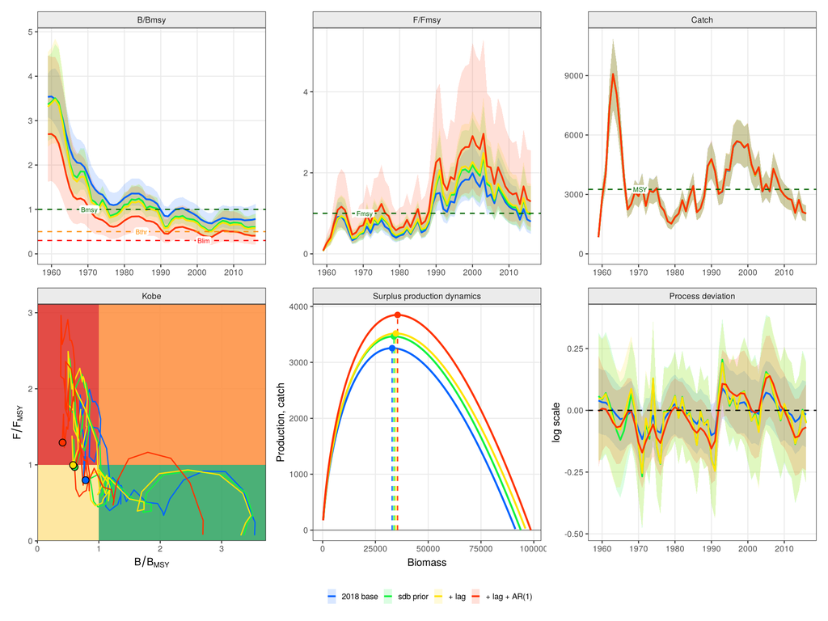

```r
jabbaplot3(bum.runs, panels = c("B/Bmsy", "F/Fmsy", "Catch", "kobe", "spdyn", "procdev"))
```

## 16.3 Diagnostics

Retrospective patterns and index prediction skill do not distinguish the runs; both are acceptable in all of them. As in the simulations, the standard diagnostics cannot tell whether a model is optimistic about rebuilding.

```r
bum.hc <- lapply(bum.runs, jb3_hindcast, n = 5)
bum.rt <- lapply(bum.runs, jb3_retro, n = 5)
mase <- sapply(bum.hc, function(h){ m <- h$mase; stats::setNames(m$MASE, m$index)[is.finite(m$MASE)] })
mohn <- sapply(bum.rt, function(r) stats::setNames(r$rho$rho, r$rho$quantity))
knitr::kable(round(rbind(mase, mohn[c("B/Bmsy", "F/Fmsy"), , drop = FALSE]), 2),
             caption = "Hindcast MASE by index and Mohn's rho")
```

Hindcast MASE by index and Mohn’s rho

|  | 2018 base | sdb prior | + lag | + lag + AR(1) |
| --- | --- | --- | --- | --- |
| BRA.Rec | 0.56 | 0.57 | 0.57 | 0.58 |
| USA.LL | 0.87 | 0.90 | 0.89 | 0.94 |
| VEN.GIL | 0.40 | 0.20 | 0.20 | 0.08 |
| B/Bmsy | 0.09 | 0.08 | 0.08 | 0.07 |
| F/Fmsy | -0.11 | -0.10 | -0.10 | -0.08 |

Hindcasts for the two indices that extend to the end of the series and dominate the recent trend (US and Brazilian recreational/longline CPUE), for the 2018 base case and the protocol:

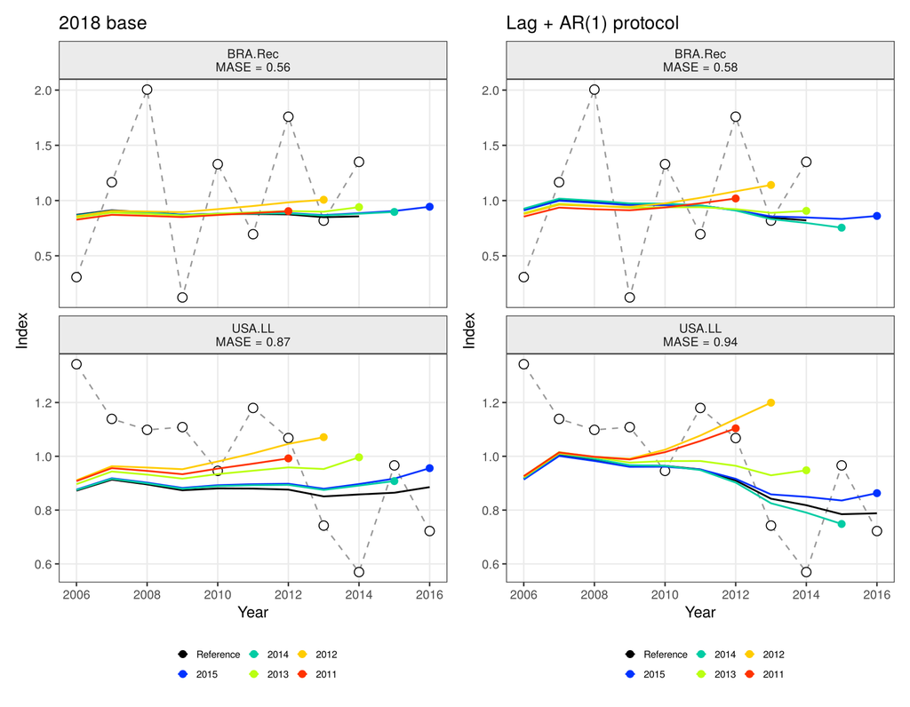

```r
patchwork::wrap_plots(
  jbplot_hcxval(bum.hc$`2018 base`, indices = c("USA.LL", "BRA.Rec"), ncol = 1) + ggplot2::ggtitle("2018 base"),
  jbplot_hcxval(bum.hc$`+ lag + AR(1)`, indices = c("USA.LL", "BRA.Rec"), ncol = 1) + ggplot2::ggtitle("Lag + AR(1) protocol"),
  ncol = 2)
```

## 16.4 Forecasts

The runs differ most in their forecasts. Constant-catch projections of 1500, 2000 and 2500 t, with the AR(1) process continued from the last estimated deviation in the persistent model:

```r
bum.pc <- lapply(bum.runs[c("2018 base", "+ lag + AR(1)")], jb3_project,
                 catch = c(1500, 2000, 2500), nyears = 10)
lapply(bum.pc, function(p) knitr::kable(jb3_kobematrix(p)[, c(1, 2, 4, 6, 11)],
       caption = "P(green) by year"))
```

```
#> $`2018 base`
#>
#>
#> Table: P(green) by year
#>
#> |             |scenario     | 2017| 2019| 2021| 2026|
#> |:------------|:------------|----:|----:|----:|----:|
#> |Catch = 1500 |Catch = 1500 | 0.15| 0.35| 0.56| 0.86|
#> |Catch = 2000 |Catch = 2000 | 0.16| 0.30| 0.48| 0.73|
#> |Catch = 2500 |Catch = 2500 | 0.16| 0.25| 0.35| 0.53|
#>
#> $`+ lag + AR(1)`
#>
#>
#> Table: P(green) by year
#>
#> |             |scenario     | 2017| 2019| 2021| 2026|
#> |:------------|:------------|----:|----:|----:|----:|
#> |Catch = 1500 |Catch = 1500 | 0.01| 0.04| 0.13| 0.36|
#> |Catch = 2000 |Catch = 2000 | 0.01| 0.03| 0.08| 0.26|
#> |Catch = 2500 |Catch = 2500 | 0.01| 0.04| 0.09| 0.21|
```

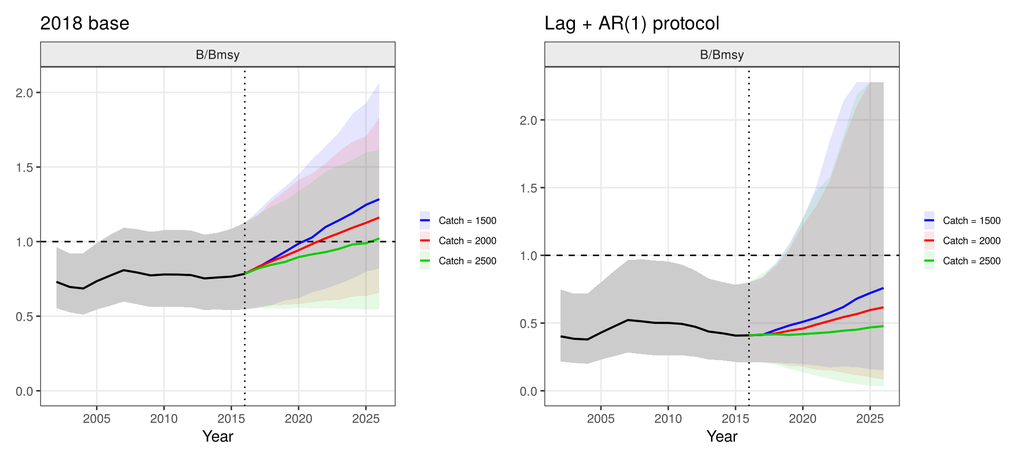

```r
patchwork::wrap_plots(
  jbplot_projection(bum.pc$`2018 base`, type = "B/Bmsy") + ggplot2::ggtitle("2018 base"),
  jbplot_projection(bum.pc$`+ lag + AR(1)`, type = "B/Bmsy") + ggplot2::ggtitle("Lag + AR(1) protocol"))
```

# 17 FLR outputs

`jb3_flqs()` returns the time series as `FLQuants` (`stock` = B/Bmsy, `harvest` = F/Fmsy, `biomass`, `F` and `catch`), with the draws as iterations when the fit has draws; `jb3_flpar()` returns parameters, reference points and current status as an `FLPar`.

```r
fq <- jb3_flqs(fit)
names(fq)
```

```
#> [1] "stock"   "harvest" "biomass" "F"       "catch"
```

```r
dim(fq$stock)
```

```
#> [1]  1 48  1  1  1  1
```

```r
jb3_flpar(fit)
```

```
#> An object of class "FLPar"
#> params
#>        K        r        m     Bmsy     Fmsy      MSY    BmsyK      sdb
#> 1.83e+05 3.94e-01 2.00e+00 9.14e+04 1.97e-01 1.80e+04 5.00e-01 1.17e-01
#>   B.Bmsy   F.Fmsy
#> 4.22e-01 3.02e+00
#> units:  NA NA NA NA NA NA NA NA NA NA
```

These plot with ggplotFL and can be used in FLR workflows (e.g. as the output of an estimator in `mse`):

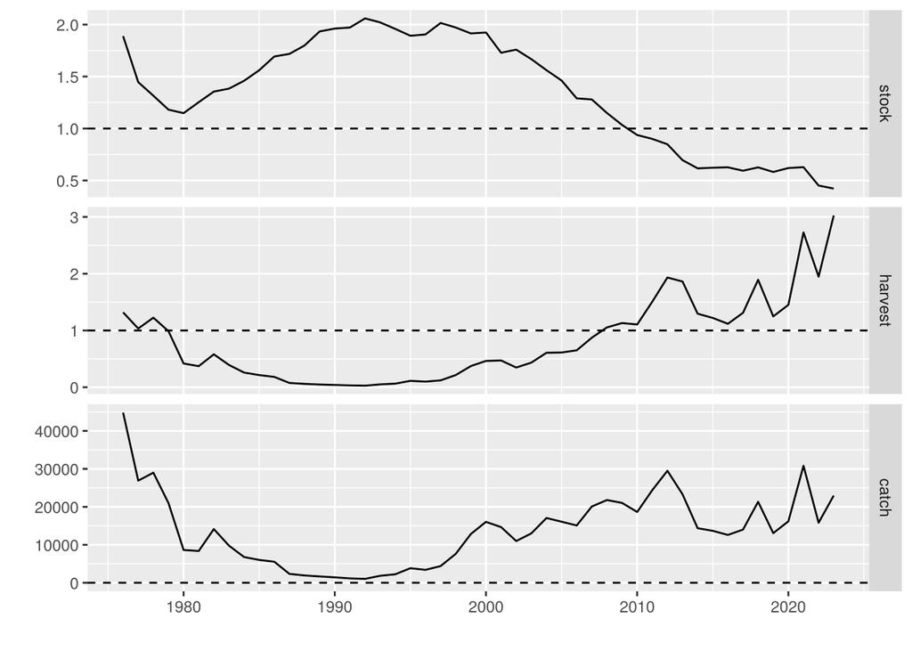

```r
library(ggplotFL)
plot(fq[c("stock", "harvest", "catch")]) + ggplot2::geom_hline(yintercept = 1, linetype = 2)
```

## 17.1 FLStockR

`jb3_FLStockR()` converts the fit to a biomass-dynamic `FLStockR`, as `FLRef::jabba2FLStockR()`: biomass in `stock` (and `ssb()`), catch, and the harvest rate in `harvest`, with the draws as iterations. The `refpts` slot holds $F_{MSY}$, $B_{MSY}$, MSY, $B_{thr}$ and $B_{lim}$ (by default 0.5 and 0.3 $B_{MSY}$, the SPiCT benchmark defaults) and $B_0$. Advice from surplus production models is given in relative terms, so by default the stock is in $B/B_{MSY}$ and $F/F_{MSY}$; `rel = FALSE` gives absolute biomass and harvest rate.

```r
stk <- jb3_FLStockR(fit, ndraws = 500)        # relative (B/Bmsy, F/Fmsy) by default
stk@refpts
```

```
#> An object of class "FLPar"
#> params
#>    Fmsy    Bmsy     MSY    Bthr    Blim      B0
#>     1.0     1.0 17988.8     0.5     0.3     2.0
#> units:  NA
```

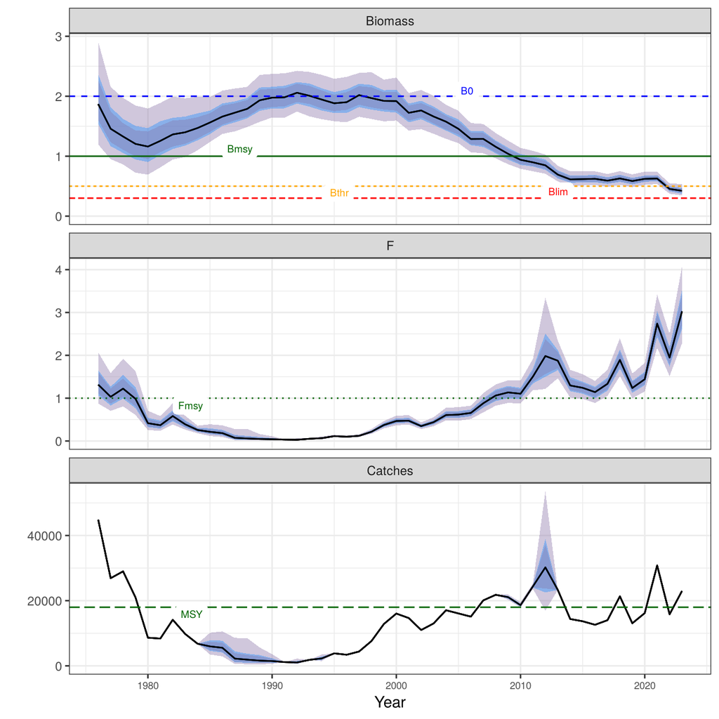

```r
FLRef::plotAdvice(stk, type = "spm") + ggplot2::facet_wrap(~qname, ncol = 1, scales = "free_y")
```

Absolute biomass and harvest rate with `rel = FALSE`:

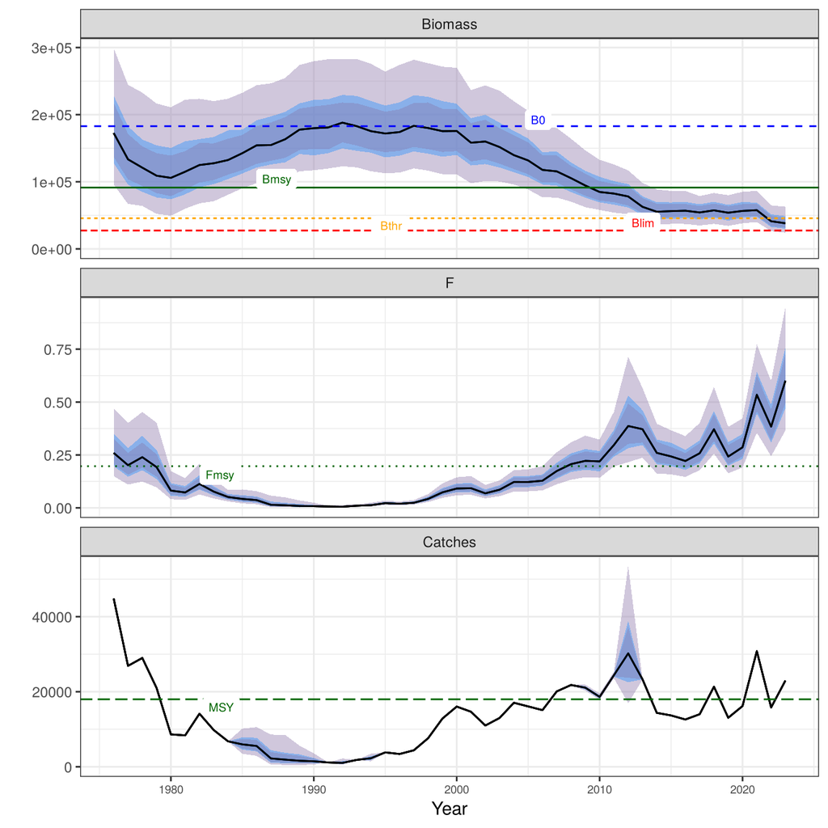

```r
FLRef::plotAdvice(jb3_FLStockR(fit, rel = FALSE, ndraws = 500), type = "spm") +
  ggplot2::facet_wrap(~qname, ncol = 1, scales = "free_y")
```

# 18 Converting from JABBA and SPiCT

## 18.1 JABBA: `jbinput2jabba3()`

`jbinput2jabba3()` takes the object returned by `JABBA::build_jabba()` and returns `list(data, priors, model)` for `jabba3()`. It carries over the priors (r, K, psi to `bkinit`, shape, catchability, status priors), the production lag, catch error, catchability and variance groups, `proc.dev.all`, the BioProcDyn process-error options and the Selex curves, and reports each difference:

- JABBA’s inverse-gamma prior on the process variance is replaced by the FishLife prior (`keep.igamma = TRUE` keeps it);
- q gets a flat prior on log q (`q.uniform = TRUE` reproduces the JAGS uniform prior on q);
- auxiliary data are not yet supported and are dropped.

```r
jb <- JABBA::build_jabba(catch = bet$catch, cpue = bet$cpue, se = bet$se, model.type = "Fox",
                         r.prior = c(0.2, 0.5), psi.prior = c(0.9, 0.25), verbose = FALSE)
options(scipen = 0)          # build_jabba() sets options(scipen = 999)
x  <- jbinput2jabba3(jb)
f2 <- jabba3(x$data, x$priors, x$model, osa = FALSE)
signif(f2$pars[c("K", "r", "sdb"), c("est", "lci", "uci")], 4)
```

```
#>           est       lci       uci
#> K   1.175e+06 6.887e+05 2.004e+06
#> r   1.929e-01 1.068e-01 3.486e-01
#> sdb 9.452e-02 6.314e-02 1.415e-01
```

> With the same process-error prior, the conversion reproduces the JABBA (RTMB engine) fit of bigeye exactly (K = 1,174,749; $B/B_{MSY}$ = 0.797 in 2017).

## 18.2 SPiCT: `spictinp2jabba3()`

`spictinp2jabba3()` takes a SPiCT input list (`inp`, as passed to `spict::fit.spict()`). JABBA3 is an annual model: catches are summed by calendar year and several index observations in a year are averaged (geometric mean). SPiCT’s observation-error form is used (`obs.error = "spict"`), with `stdevfacI` as relative weights. The priors `logr`, `logK`, `logbkfrac`, `logsdb`, `logn` and `logsdi` carry over with their on/off switches, and a fixed `n` (phase -1) fixes the shape. The `alpha` and `beta` priors (ratios of observation to process SDs) and the F process have no JABBA3 equivalent and are reported as dropped.

A SPiCT-style input list built from the bigeye data:

```r
ok1 <- is.finite(bet$cpue[, 2]); ok2 <- is.finite(bet$cpue[, 3])
inp <- list(obsC = bet$catch[, 2], timeC = bet$catch[, 1],
            obsI = list(bet$cpue[ok1, 2], bet$cpue[ok2, 3]),
            timeI = list(bet$cpue[ok1, 1] + 0.5, bet$cpue[ok2, 1] + 0.5),
            priors = list(logr = c(log(0.2), 0.5, 1), logn = c(log(2), 2, 0), logbkfrac = c(log(0.8), 0.5, 1)),
            ini = list(logn = log(2)), phases = list(logn = -1))
xs <- spictinp2jabba3(inp, stock = "bet")
fs <- jabba3(xs$data, xs$priors, xs$model, osa = FALSE)
signif(fs$pars[c("K", "r", "sdb"), c("est", "lci", "uci")], 4)
```

```
#>           est       lci       uci
#> K   1.566e+06 7.260e+05 3.377e+06
#> r   2.352e-01 1.028e-01 5.382e-01
#> sdb 1.292e-01 1.049e-01 1.593e-01
```

With the spict package installed, its example data convert the same way:

```r
data(pol, package = "spict")
xp <- spictinp2jabba3(pol$albacore, stock = "albacore")
fp <- jabba3(xp$data, xp$priors, xp$model)
fp
```

# 19 Model equations

**Process equation.** Biomass relative to K, $P_t = B_t/K$, with process error acting after the catch (Winker et al. 2018) and a production lag $L$:

$$\log P_t = \log\left[P_{t-1} + \frac{r}{m-1} P_{t-1-L}\left(1 - P_{t-1-L}^{\,m-1}\right) - \frac{C_{t-1}}{K}\right] + d_t ,$$

where $m$ is the Pella-Tomlinson shape ($m = 2$ Schaefer, $m \to 1$ Fox) and $P_1$ = `bkinit`. Years before the start use the initial depletion for the lagged term.

**Process deviations.** Stationary AR(1), with $\sigma_t$ the marginal SD:

$$d_1 \sim N(0, \sigma_1^2), \qquad d_t \sim N\left(\rho\, d_{t-1},\ \sigma_t^2 (1-\rho^2)\right),$$

$\rho = 0$ giving the independent process error of JABBA and SPiCT. Either $\sigma_t = \sigma_{MSY}$ (constant) or $\sigma_t = \sigma_{MSY} x_t^{-k}$ with $x_t = B_t/B_{MSY}$ bounded to `xlim` (dynamic).

**Reference points.**

$$\frac{B_{MSY}}{K} = m^{-1/(m-1)}, \qquad F_{MSY} = \frac{r}{m}, \qquad MSY = F_{MSY} B_{MSY}.$$

**Observations.** Index $i$ in year $t$:

$$\log I_{i,t} = \log q_i + \log(K P_t) + \varepsilon_{i,t}, \qquad
\varepsilon_{i,t} \sim N\left(0,\ se_{i,t}^2 + sdi_i^2\right)$$

(`obs.error = "additive"`), or $\varepsilon_{i,t} \sim N(0, (sdi_i\,w_{i,t})^2)$ (`obs.error = "spict"`). Catch: $\log C^{obs}_t \sim N(\log C_t, sdc^2)$ when `catch.error = TRUE`.

**Estimation.** The states $\log P_t$ and catch deviations are random effects, integrated by the Laplace approximation (`engine = "rtmb"`) or sampled with the fixed effects (`engine = "nuts"`).

# 20 Summary of checks and functions

| # | Check | Red flag | Action |
| --- | --- | --- | --- |
| 1 | data (`jbplot_data`) | no contrast; conflicting indices | r prior, status priors; separate `sdi`; sensitivity runs |
| 2 | prior and posterior (`jbplot_priorpost`) | posterior = prior; posterior at the edge | report; revisit priors |
| 3 | convergence (`jb3_convergence`) | gradient, Hessian, Newton decrement | restarts; priors on r or K; fewer groups |
| 4 | residuals (`jbplot_residuals`, `jbplot_runs`, `jb3_diags`) | trends, failed runs or Ljung-Box tests | lag + AR(1); index conflict |
| 5 | retrospective (`jb3_retro`) | Mohn’s rho beyond -0.15 to 0.20 | recent data, q |
| 6 | hindcast (`jb3_hindcast`) | MASE > 1 | index without prediction skill |
| 7 | process deviations (`jbplot_procdev`) | long runs of one sign | `rho = 0.75`, `lag = amat` |
| 8 | NUTS (`jb3_nuts_diags`, `jbplot_nuts`) | $\hat{R} > 1.01$, low ESS, divergences, E-BFMI < 0.3 | longer chains; `adapt_delta`; priors |

| Topic | Recommendation |
| --- | --- |
| Process error | lag at the age at maturity + AR(1) with $\rho = 0.75$ (sensitivity 0.5, 0.9); FishLife prior on $\sigma_{MSY}$ |
| Shape | Pella with $B_{MSY}/K = 0.4$ unless known; convert the r prior with the shape |
| Engine | posterior mode for exploration, diagnostics, retro and hindcast; NUTS for final runs |
| Simulation testing and MSE | `se = FALSE, osa = FALSE` |

## 20.1 Function reference

[output not shown]

*Planned: auxiliary data (effort), multi-fleet Selex, non-centred NUTS for the states, a worked simulation-testing example.*

# 21 References

Carvalho, F., Winker, H., Courtney, D., Kapur, M., Kell, L., Cardinale, M., Schirripa, M., Kitakado, T., Yemane, D., Piner, K.R., Maunder, M.N., Taylor, I., Wetzel, C.R., Doering, K., Johnson, K.F. and Methot, R.D. (2021). A cookbook for using model diagnostics in integrated stock assessments. *Fisheries Research* 240: 105959.

Conn, P.B. (2010). Hierarchical analysis of multiple noisy abundance indices. *Canadian Journal of Fisheries and Aquatic Sciences*, 67, 108-120. doi:10.1139/F09-175

Kell, L.T., Sharma, R., Kitakado, T., Winker, H., Mosqueira, I., Cardinale, M. and Fu, D. (2021). Validation of stock assessment methods: is it me or my model talking? *ICES Journal of Marine Science* 78(6): 2244-2255.

Kell, L.T., Mosqueira, I., Grosjean, P., Fromentin, J.-M., Garcia, D., Hillary, R., Jardim, E., Mardle, S., Pastoors, M.A., Poos, J.J., Scott, F. and Scott, R.D. (2007). FLR: an open-source framework for the evaluation and development of management strategies. *ICES Journal of Marine Science* 64(4): 640-646.

Kristensen, K., Nielsen, A., Berg, C.W., Skaug, H. and Bell, B.M. (2016). TMB: automatic differentiation and Laplace approximation. *Journal of Statistical Software* 70(5): 1-21.

Monnahan, C.C. and Kristensen, K. (2018). No-U-turn sampling for fast Bayesian inference in ADMB and TMB: introducing the adnuts and tmbstan R packages. *PLoS ONE* 13(5): e0197954.

Pedersen, M.W. and Berg, C.W. (2017). A stochastic surplus production model in continuous time. *Fish and Fisheries* 18(2): 226-243.

Thorson, J.T. (2020). Predicting recruitment density dependence and intrinsic growth rate for all fishes worldwide using a data-integrated life-history model. *Fish and Fisheries* 21(2): 237-251.

Thygesen, U.H., Albertsen, C.M., Berg, C.W., Kristensen, K. and Nielsen, A. (2017). Validation of ecological state space models using the Laplace approximation. *Environmental and Ecological Statistics* 24(2): 317-339.

Vehtari, A., Gelman, A., Simpson, D., Carpenter, B. and Bürkner, P.-C. (2021). Rank-normalization, folding, and localization: an improved $\hat{R}$ for assessing convergence of MCMC. *Bayesian Analysis* 16(2): 667-718.

Winker, H., Carvalho, F. and Kapur, M. (2018). JABBA: Just Another Bayesian Biomass Assessment. *Fisheries Research* 204: 275-288.

Winker, H. et al. (2026). Process error in surplus production models: scale, persistence and inflation (BioProcDyn). In preparation.